# Oxygen estimation

Laura Segura Hernández

2022-08-07

# 1 Description

This is the final code to use. The other script for oxygen estimation for some reason lost part of the code. I made this copy after that, with hopefully the whole code again. Use this file for the oxygen estimation, not the other (incomplete) one.

In this script I achieve the following:

1. Wrangle the oxygen and temperature data to create the oxygen consumption rate per temperature for all individuals exposed to the thermolimit respirometry trials.
2. Obtain the estimates of metrics relevant to the physiological responses to temperature (Topt, Ropt, Activation energy)

# 2 Libraries

```r
library(data.table)
library(tidyr)
library(dplyr)
library(lubridate)
library(ggplot2)
library(fuzzyjoin)
library(forcats)
library(ggpubr)
library(readr)
library(stringr)
library(purrr)
library(knitr)
library(magick)
library(jpeg)
library(grid)
```

# 3 Organizing data

## 3.1 Getting objects from Temperature Analyses

```r
load("Outputs/Temperature analyses.RData")

#I need to correct the measurments for the volume of the container. The genitalia vial had an internal dimension of 2 mm diameter and 4 mm height. Calculating the volume of the cylinder by h*pi*(r^2), I get 12.5663706143592 mm3
volume<- 12.5663706143592*10^(-6) #converting to Liters
volume
```

```
## [1] 1.256637e-05
```

## 3.2 Calling and arranging data

> This is what this part of the code does, per trial:
1. Prepares the files associated with the trial and brings them into R
2. Merges them into a single file
3. Manually adds the information missing to each one. Eg: IDs, weights, stages, etc.
4. It then call the temperature data and adds it to the file as well
5. Finally, it add the oxygen data (based on the calculations of the spreadsheet that Jon DeLong provided me) and convert it to mg O2 instead of mg/L

### 3.2.1 Trial 2

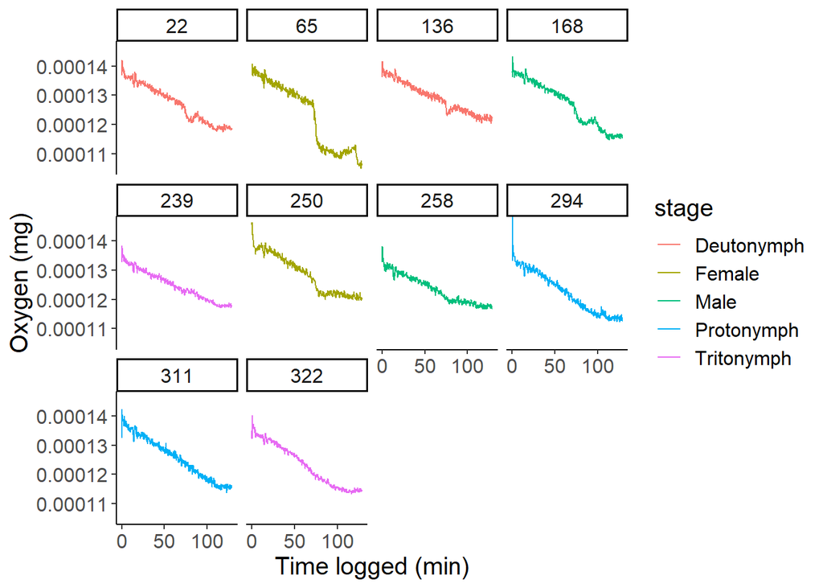

```r
# creating vector for columns names
cnames<-c("date", "time", "logtime", "oxygen", "phase", "amplitude", "temperature")

# creating vector for path
path<-"Data/Oxygen/Trial 2/" #MODIFY FOR EACH TRIAL

# Creating list of file names
list <- list.files(path = path, pattern=".*txt") # creates the list of all the txt files in the directory

# Renaming files to remove the "-"
newname <- sub('-','', list) ## new name
file.rename(file.path(path,list), file.path(path, newname)) ## renaming it.

# Creating list of file names again
list <- list.files(path = path, pattern=".*txt") # creates the list of all the txt files in the directory

#Reading all files at once
for (i in list) {
  filename <- paste0( "frame",sub(pattern = "(.*)\\..*$", replacement = "\\1", basename(i)))
  wd <- paste0(path, i)
  assign(filename, read.delim2(wd,sep=";", skip=38, header=F, col.names=cnames)) #CHECK FOR EACH TRIALS IF THE SAME NUMBRE OF ROWS APPLIES

}


# Merging all into a single table
pattern<-grep("framepstrial2",names(.GlobalEnv),value=TRUE) #MODIFY FOR EACH TRIAL
list2<-do.call("list",mget(pattern))

t2a<-bind_rows(list2, .id="id") #MODIFY FOR EACH TRIAL


# Adding and modifying data to phase files
t2b<-t2a %>% #MODIFY FOR EACH TRIAL
  select(c("id", "date", "time", "logtime", "phase")) %>%
  mutate(trial=2,#MODIFY FOR EACH TRIAL
         date=mdy(date), #formatting date
         datetime=paste0(date," ", time), #copying date and time together
         datetime=as_datetime(datetime, format="%Y-%m-%d %I:%M:%S %p")-minutes(9), #adjusting pc time to real time
         datetime2=round_date(datetime, unit="minute"),
         channel=case_when(str_detect(id, "ch10")~10, # Assigning channels
                       str_detect(id, "ch1")~1,
                       str_detect(id, "ch2")~2,
                       str_detect(id, "ch3")~3,
                       str_detect(id, "ch4")~4,
                       str_detect(id, "ch5")~5,
                       str_detect(id, "ch6")~6,
                       str_detect(id, "ch7")~7,
                       str_detect(id, "ch8")~8,
                       str_detect(id, "ch9")~9,
                       TRUE~0),
         ind=case_when(str_detect(id, "ch10")~250, # Assigning individuals MODIFY FOR EACH TRIAL
                       str_detect(id, "ch1")~239,
                       str_detect(id, "ch2")~311,
                       str_detect(id, "ch3")~65,
                       str_detect(id, "ch4")~136,
                       str_detect(id, "ch5")~168,
                       str_detect(id, "ch6")~294,
                       str_detect(id, "ch7")~322,
                       str_detect(id, "ch8")~022,
                       str_detect(id, "ch9")~258,
                       TRUE~0),
         stage=case_when(str_detect(id, "ch10")~"Female",#Assigning stage MODIFY FOR EACH TRIAL
                       str_detect(id, "ch1")~"Tritonymph",
                         str_detect(id, "ch2")~"Protonymph",
                       str_detect(id, "ch3")~"Female",
                       str_detect(id, "ch4")~"Deutonymph",
                       str_detect(id, "ch5")~"Male",
                       str_detect(id, "ch6")~"Protonymph",
                       str_detect(id, "ch7")~"Tritonymph",
                       str_detect(id, "ch8")~"Deutonymph",
                       #str_detect(id, "ch9")~"Male",
                       TRUE~"Male"),
         weight=case_when(str_detect(id, "ch10")~1.269, # Assigning weights MODIFY FOR EACH TRIAL
                       str_detect(id, "ch1")~0.792,
                       str_detect(id, "ch2")~0.189,
                       str_detect(id, "ch3")~1.714,
                       str_detect(id, "ch4")~0.330,
                       str_detect(id, "ch5")~1.219,
                       str_detect(id, "ch6")~0.240,
                       str_detect(id, "ch7")~0.749,
                       str_detect(id, "ch8")~0.339,
                       #str_detect(id, "ch9")~1.001,
                       TRUE~1.001),
         atm=round(33.864*28.81)) #MODIFY FOR EACH TRIAL: 33.864 * pressure in inHg

# Getting temperature for this trial
temp2<-all_corr %>%
  filter(trial==2) %>% #MODIFY FOR EACH TRIAL
  select(c("datetime2","datetime", "tempcorr", "ramp"))

#Merging phase and temperature data
t2<- full_join(t2b, temp2, by="datetime2", suffix=c("",".temp"))


head(t2) #MODIFY FOR EACH TRIAL

#Estimating Oxygen
f<-pi/180
f


ox2<-t2 %>% #MODIFY FOR EACH TRIAL
  na.omit() %>%
  mutate(phase=as.numeric(phase),
         ind=as.factor(ind),
         logtime=as.numeric(logtime),
         phaseangle=62.14-0.08915*tempcorr,
         sternvolmer=0.04899+4.965*10^(-4)*tempcorr,
         bunsen=(48.998-1.335*tempcorr+2.755*10^(-2)*tempcorr^2-3.22*10^(-4)*tempcorr^3+1.598*10^(-6)*tempcorr^4)*10^(-3),
         tempK=tempcorr+273,
         watervapor=exp(52.57-(6690.9/tempK)-4.681*log(tempK)),
         oxysat=(tan((pi/180)*phaseangle)-tan((pi/180)*phase))/tan((pi/180)*phase)*sternvolmer,
         oxymgl=(atm-watervapor)/1013*oxysat*0.2095*bunsen*1000*(32/22.414)*10,
         oxymg=oxymgl*volume)

head(ox2) #MODIFY FOR EACH TRIAL

ggplot(ox2, aes(x=logtime, y=oxymg,group=ind, color=stage))+ #MODIFY FOR EACH TRIAL
  geom_line()+
  theme_classic()+
  theme(text = element_text(size = 15))+
 # ylim(8.5,12) +
  facet_wrap(~ind)+
  xlab("Time logged (min)")+
  ylab("Oxygen (mg)")
```

### 3.2.2 Trial 3

```r
# creating vector for columns names
cnames<-c("date", "time", "logtime", "oxygen", "phase", "amplitude", "temperature")

# creating vector for path
path<-"Data/Oxygen/Trial 3/" #MODIFY FOR EEACH TRIAL

# Creating list of file names
list <- list.files(path = path, pattern=".*txt") # creates the list of all the txt files in the directory

# Renaming files to remove the "-"
newname <- sub('-','', list) ## new name
file.rename(file.path(path,list), file.path(path, newname)) ## renaming it.
```

```
##  [1] TRUE TRUE TRUE TRUE TRUE TRUE TRUE TRUE TRUE TRUE
```

```r
# Creating list of file names again
list <- list.files(path = path, pattern=".*txt") # creates the list of all the txt files in the directory

#Reading all files at once
for (i in list) {
  filename <- paste0( "frame",sub(pattern = "(.*)\\..*$", replacement = "\\1", basename(i)))
  wd <- paste0(path, i)
  assign(filename, read.delim2(wd,sep=";", skip=38, header=F, col.names=cnames)) #CHECK FOR EACH TRIALS IF THE SAME NUMBRE OF ROWS APPLIES

}


# Merging all into a single table
pattern<-grep("framepstrial3",names(.GlobalEnv),value=TRUE) #MODIFY FOR EACH TRIAL
list2<-do.call("list",mget(pattern))

t3a<-bind_rows(list2, .id="id") #MODIFY FOR EACH TRIAL


# Adding and modifying data to phase files
t3b<-t3a %>% #MODIFY FOR EACH TRIAL
  select(c("id", "date", "time", "logtime", "phase")) %>%
  mutate(trial=3,#MODIFY FOR EACH TRIAL
         date=mdy(date), #formatting date
         datetime=paste0(date," ", time), #copying date and time together
         datetime=as_datetime(datetime, format="%Y-%m-%d %I:%M:%S %p")-minutes(9), #adjusting pc time to real time
         datetime2=round_date(datetime, unit="minute"),
         channel=case_when(str_detect(id, "ch10")~10, # Assigning channels
                       str_detect(id, "ch1")~1,
                       str_detect(id, "ch2")~2,
                       str_detect(id, "ch3")~3,
                       str_detect(id, "ch4")~4,
                       str_detect(id, "ch5")~5,
                       str_detect(id, "ch6")~6,
                       str_detect(id, "ch7")~7,
                       str_detect(id, "ch8")~8,
                       str_detect(id, "ch9")~9,
                       TRUE~0),
         ind=case_when(str_detect(id, "ch10")~010, # Assigning individuals MODIFY FOR EACH TRIAL
                       str_detect(id, "ch1")~231,
                       str_detect(id, "ch2")~029,
                       str_detect(id, "ch3")~087,
                       str_detect(id, "ch4")~166,
                       str_detect(id, "ch5")~300,
                       str_detect(id, "ch6")~121,
                       str_detect(id, "ch7")~014,
                       str_detect(id, "ch8")~271,
                       str_detect(id, "ch9")~143,
                       TRUE~0),
         stage=case_when(str_detect(id, "ch10")~"Female",#Assigning stage MODIFY FOR EACH TRIAL
                       str_detect(id, "ch1")~"Tritonymph",
                         str_detect(id, "ch2")~"Male",
                       str_detect(id, "ch3")~"Protonymph",
                       str_detect(id, "ch4")~"Female",
                       str_detect(id, "ch5")~"Deutonymph",
                       str_detect(id, "ch6")~"Protonymph",
                       str_detect(id, "ch7")~"Deutonymph",
                       str_detect(id, "ch8")~"Tritonymph",
                       #str_detect(id, "ch9")~"Male",
                       TRUE~"Male"),
         weight=case_when(str_detect(id, "ch10")~1.228, # Assigning weights MODIFY FOR EACH TRIAL
                       str_detect(id, "ch1")~0.931,
                       str_detect(id, "ch2")~0.924,
                       str_detect(id, "ch3")~0.251,
                       str_detect(id, "ch4")~1.376,
                       str_detect(id, "ch5")~0.289,
                       str_detect(id, "ch6")~0.189,
                       str_detect(id, "ch7")~0.347,
                       str_detect(id, "ch8")~0.647,
                       #str_detect(id, "ch9")~1.001,
                       TRUE~1.021),
         atm=round(33.864*28.81)) #MODIFY FOR EACH TRIAL: 33.864 * pressure in inHg

# Getting temperature for this trial
temp2<-all_corr %>%
  filter(trial==3) %>% #MODIFY FOR EACH TRIAL
  select(c("datetime2","datetime", "tempcorr", "ramp"))

#Merging phase and temperature data
t3<- full_join(t3b, temp2, by="datetime2", suffix=c("",".temp")) #MODIFY FOR EACH TRIAL


head(t3) #MODIFY FOR EACH TRIAL
```

|  | id | date | time | logtime | phase | trial | datetime | datetime2 | channel | ind | stage | weight | atm | datetime.temp | tempcorr | ramp |
| --- | --- | --- | --- | --- | --- | --- | --- | --- | --- | --- | --- | --- | --- | --- | --- | --- |
| 1 | framepstrial3ch8 | 2022-06-21 | 6:29:03 PM | 0.00 | 27.680 | 3 | 2022-06-21 18:20:03 | 2022-06-21 18:20:00 | 8 | 271 | Tritonymph | 0.647 | 976 | 2022-06-21 18:19:37 | 24.85344 | 0.2499655 |
| 2 | framepstrial3ch8 | 2022-06-21 | 6:29:04 PM | 0.03 | 27.610 | 3 | 2022-06-21 18:20:04 | 2022-06-21 18:20:00 | 8 | 271 | Tritonymph | 0.647 | 976 | 2022-06-21 18:19:37 | 24.85344 | 0.2499655 |
| 3 | framepstrial3ch8 | 2022-06-21 | 6:29:12 PM | 0.15 | 27.710 | 3 | 2022-06-21 18:20:12 | 2022-06-21 18:20:00 | 8 | 271 | Tritonymph | 0.647 | 976 | 2022-06-21 18:19:37 | 24.85344 | 0.2499655 |
| 4 | framepstrial3ch8 | 2022-06-21 | 6:29:26 PM | 0.39 | 27.710 | 3 | 2022-06-21 18:20:26 | 2022-06-21 18:20:00 | 8 | 271 | Tritonymph | 0.647 | 976 | 2022-06-21 18:19:37 | 24.85344 | 0.2499655 |
| 5 | framepstrial3ch8 | 2022-06-21 | 6:29:41 PM | 0.63 | 27.800 | 3 | 2022-06-21 18:20:41 | 2022-06-21 18:21:00 | 8 | 271 | Tritonymph | 0.647 | 976 | 2022-06-21 18:20:37 | 24.93251 | 0.2499655 |
| 6 | framepstrial3ch8 | 2022-06-21 | 6:29:56 PM | 0.89 | 27.820 | 3 | 2022-06-21 18:20:56 | 2022-06-21 18:21:00 | 8 | 271 | Tritonymph | 0.647 | 976 | 2022-06-21 18:20:37 | 24.93251 | 0.2499655 |

```r
#Estimating Oxygen
f<-pi/180
f
```

```
## [1] 0.01745329
```

```r
ox3<-t3 %>% #MODIFY FOR EACH TRIAL
  na.omit() %>%
  mutate(phase=as.numeric(phase),
         ind=as.factor(ind),
         logtime=as.numeric(logtime),
         phaseangle=62.14-0.08915*tempcorr,
         sternvolmer=0.04899+4.965*10^(-4)*tempcorr,
         bunsen=(48.998-1.335*tempcorr+2.755*10^(-2)*tempcorr^2-3.22*10^(-4)*tempcorr^3+1.598*10^(-6)*tempcorr^4)*10^(-3),
         tempK=tempcorr+273,
         watervapor=exp(52.57-(6690.9/tempK)-4.681*log(tempK)),
         oxysat=(tan((pi/180)*phaseangle)-tan((pi/180)*phase))/tan((pi/180)*phase)*sternvolmer,
         oxymgl=(atm-watervapor)/1013*oxysat*0.2095*bunsen*1000*(32/22.414)*10,
         oxymg=oxymgl*volume)

head(ox3) #MODIFY FOR EACH TRIAL
```

|  | id | date | time | logtime | phase | trial | datetime | datetime2 | channel | ind | stage | weight | atm | datetime.temp | tempcorr | ramp | phaseangle | sternvolmer | bunsen | tempK | watervapor | oxysat | oxymgl | oxymg |
| --- | --- | --- | --- | --- | --- | --- | --- | --- | --- | --- | --- | --- | --- | --- | --- | --- | --- | --- | --- | --- | --- | --- | --- | --- |
| 1 | framepstrial3ch8 | 2022-06-21 | 6:29:03 PM | 0.00 | 27.68 | 3 | 2022-06-21 18:20:03 | 2022-06-21 18:20:00 | 8 | 271 | Tritonymph | 0.647 | 976 | 2022-06-21 18:19:37 | 24.85344 | 0.2499655 | 59.92432 | 0.06132973 | 0.02850254 | 297.8534 | 31.20180 | 0.1405568 | 11.17582 | 0.0001404396 |
| 2 | framepstrial3ch8 | 2022-06-21 | 6:29:04 PM | 0.03 | 27.61 | 3 | 2022-06-21 18:20:04 | 2022-06-21 18:20:00 | 8 | 271 | Tritonymph | 0.647 | 976 | 2022-06-21 18:19:37 | 24.85344 | 0.2499655 | 59.92432 | 0.06132973 | 0.02850254 | 297.8534 | 31.20180 | 0.1411578 | 11.22361 | 0.0001410400 |
| 3 | framepstrial3ch8 | 2022-06-21 | 6:29:12 PM | 0.15 | 27.71 | 3 | 2022-06-21 18:20:12 | 2022-06-21 18:20:00 | 8 | 271 | Tritonymph | 0.647 | 976 | 2022-06-21 18:19:37 | 24.85344 | 0.2499655 | 59.92432 | 0.06132973 | 0.02850254 | 297.8534 | 31.20180 | 0.1403001 | 11.15541 | 0.0001401831 |
| 4 | framepstrial3ch8 | 2022-06-21 | 6:29:26 PM | 0.39 | 27.71 | 3 | 2022-06-21 18:20:26 | 2022-06-21 18:20:00 | 8 | 271 | Tritonymph | 0.647 | 976 | 2022-06-21 18:19:37 | 24.85344 | 0.2499655 | 59.92432 | 0.06132973 | 0.02850254 | 297.8534 | 31.20180 | 0.1403001 | 11.15541 | 0.0001401831 |
| 5 | framepstrial3ch8 | 2022-06-21 | 6:29:41 PM | 0.63 | 27.80 | 3 | 2022-06-21 18:20:41 | 2022-06-21 18:21:00 | 8 | 271 | Tritonymph | 0.647 | 976 | 2022-06-21 18:20:37 | 24.93251 | 0.2499655 | 59.91727 | 0.06136899 | 0.02846590 | 297.9325 | 31.34939 | 0.1395653 | 11.08100 | 0.0001392479 |
| 6 | framepstrial3ch8 | 2022-06-21 | 6:29:56 PM | 0.89 | 27.82 | 3 | 2022-06-21 18:20:56 | 2022-06-21 18:21:00 | 8 | 271 | Tritonymph | 0.647 | 976 | 2022-06-21 18:20:37 | 24.93251 | 0.2499655 | 59.91727 | 0.06136899 | 0.02846590 | 297.9325 | 31.34939 | 0.1393954 | 11.06751 | 0.0001390784 |

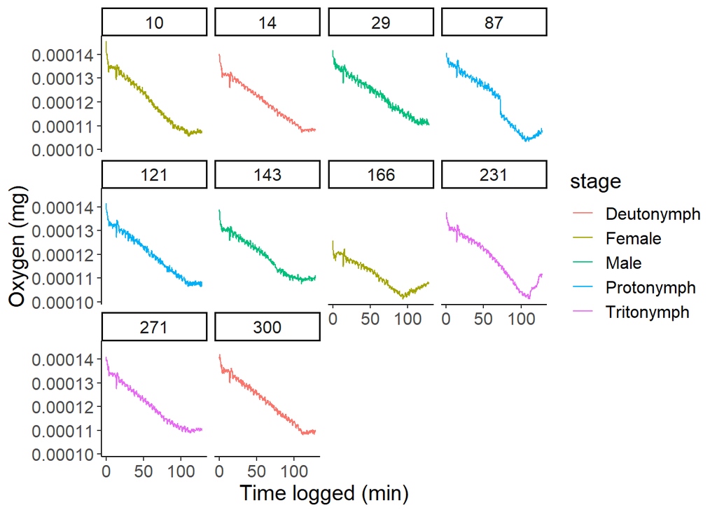

```r
ggplot(ox3, aes(x=logtime, y=oxymg,group=ind, color=stage))+ #MODIFY FOR EACH TRIAL
  geom_line()+
  theme_classic()+
  theme(text = element_text(size = 15))+
  #ylim(7,12) +
  facet_wrap(~ind)+
  xlab("Time logged (min)")+
  ylab("Oxygen (mg)")
```

### 3.2.3 Trial 4

```r
# creating vector for columns names
cnames<-c("date", "time", "logtime", "oxygen", "phase", "amplitude", "temperature")

# creating vector for path
path<-"Data/Oxygen/Trial 4/" #MODIFY FOR EEACH TRIAL

# Creating list of file names
list <- list.files(path = path, pattern=".*txt") # creates the list of all the txt files in the directory

# Renaming files to remove the "-"
newname <- sub('-','', list) ## new name
file.rename(file.path(path,list), file.path(path, newname)) ## renaming it.
```

```
##  [1] TRUE TRUE TRUE TRUE TRUE TRUE TRUE TRUE TRUE TRUE
```

```r
# Creating list of file names again
list <- list.files(path = path, pattern=".*txt") # creates the list of all the txt files in the directory

#Reading all files at once
for (i in list) {
  filename <- paste0( "frame",sub(pattern = "(.*)\\..*$", replacement = "\\1", basename(i)))
  wd <- paste0(path, i)
  assign(filename, read.delim2(wd,sep=";", skip=38, header=F, col.names=cnames)) #CHECK FOR EACH TRIALS IF THE SAME NUMBRE OF ROWS APPLIES

}


# Merging all into a single table
pattern<-grep("framepstrial4",names(.GlobalEnv),value=TRUE) #MODIFY FOR EACH TRIAL
list2<-do.call("list",mget(pattern))

t4a<-bind_rows(list2, .id="id") #MODIFY FOR EACH TRIAL


# Adding and modifying data to phase files
t4b<-t4a %>% #MODIFY FOR EACH TRIAL
  select(c("id", "date", "time", "logtime", "phase")) %>%
  mutate(trial=4,#MODIFY FOR EACH TRIAL
         date=mdy(date), #formatting date
         datetime=paste0(date," ", time), #copying date and time together
         datetime=as_datetime(datetime, format="%Y-%m-%d %I:%M:%S %p")-minutes(9), #adjusting pc time to real time
         datetime2=round_date(datetime, unit="minute"),
         channel=case_when(str_detect(id, "ch10")~10, # Assigning channels
                       str_detect(id, "ch1")~1,
                       str_detect(id, "ch2")~2,
                       str_detect(id, "ch3")~3,
                       str_detect(id, "ch4")~4,
                       str_detect(id, "ch5")~5,
                       str_detect(id, "ch6")~6,
                       str_detect(id, "ch7")~7,
                       str_detect(id, "ch8")~8,
                       str_detect(id, "ch9")~9,
                       TRUE~0),
         ind=case_when(str_detect(id, "ch10")~213, # Assigning individuals MODIFY FOR EACH TRIAL
                       str_detect(id, "ch1")~337,
                       str_detect(id, "ch2")~051,
                       str_detect(id, "ch3")~109,
                       str_detect(id, "ch4")~245,
                       str_detect(id, "ch5")~037,
                       str_detect(id, "ch6")~131,
                       str_detect(id, "ch7")~005,
                       str_detect(id, "ch8")~194,
                       str_detect(id, "ch9")~154,
                       TRUE~0),
         stage=case_when(str_detect(id, "ch10")~"Deutonymph",#Assigning stage MODIFY FOR EACH TRIAL
                       str_detect(id, "ch1")~"Protonymph",
                         str_detect(id, "ch2")~"Deutonymph",
                       str_detect(id, "ch3")~"Tritonymph",
                       str_detect(id, "ch4")~"Male",
                       str_detect(id, "ch5")~"Female",
                       str_detect(id, "ch6")~"Tritonymph",
                       str_detect(id, "ch7")~"Female",
                       str_detect(id, "ch8")~"Male",
                       #str_detect(id, "ch9")~"Male",
                       TRUE~"Protonymph"),
         weight=case_when(str_detect(id, "ch10")~0.241, # Assigning weights MODIFY FOR EACH TRIAL
                       str_detect(id, "ch1")~0.163,
                       str_detect(id, "ch2")~0.350,
                       str_detect(id, "ch3")~0.730,
                       str_detect(id, "ch4")~0.963,
                       str_detect(id, "ch5")~1.332,
                       str_detect(id, "ch6")~0.509,
                       str_detect(id, "ch7")~1.582,
                       str_detect(id, "ch8")~0.999,
                       #str_detect(id, "ch9")~1.001,
                       TRUE~0.109),
         atm=round(33.864*28.90)) #MODIFY FOR EACH TRIAL: 33.864 * pressure in inHg

# Getting temperature for this trial
temp2<-all_corr %>%
  filter(trial==4) %>% #MODIFY FOR EACH TRIAL
  select(c("datetime2","datetime", "tempcorr", "ramp"))

#Merging phase and temperature data
t4<- full_join(t4b, temp2, by="datetime2", suffix=c("",".temp")) #MODIFY FOR EACH TRIAL


head(t4) #MODIFY FOR EACH TRIAL
```

|  | id | date | time | logtime | phase | trial | datetime | datetime2 | channel | ind | stage | weight | atm | datetime.temp | tempcorr | ramp |
| --- | --- | --- | --- | --- | --- | --- | --- | --- | --- | --- | --- | --- | --- | --- | --- | --- |
| 1 | framepstrial4ch1 | 2022-06-22 | 11:17:09 AM | 0.00 | 27.620 | 4 | 2022-06-22 11:08:09 | 2022-06-22 11:08:00 | 1 | 337 | Protonymph | 0.163 | 979 | 2022-06-22 11:07:44 | 29.57785 | 0.2595864 |
| 2 | framepstrial4ch1 | 2022-06-22 | 11:17:09 AM | 0.00 | 27.620 | 4 | 2022-06-22 11:08:09 | 2022-06-22 11:08:00 | 1 | 337 | Protonymph | 0.163 | 979 | 2022-06-22 11:08:14 | 29.68691 | 0.2595864 |
| 3 | framepstrial4ch1 | 2022-06-22 | 11:17:23 AM | 0.24 | 27.690 | 4 | 2022-06-22 11:08:23 | 2022-06-22 11:08:00 | 1 | 337 | Protonymph | 0.163 | 979 | 2022-06-22 11:07:44 | 29.57785 | 0.2595864 |
| 4 | framepstrial4ch1 | 2022-06-22 | 11:17:23 AM | 0.24 | 27.690 | 4 | 2022-06-22 11:08:23 | 2022-06-22 11:08:00 | 1 | 337 | Protonymph | 0.163 | 979 | 2022-06-22 11:08:14 | 29.68691 | 0.2595864 |
| 5 | framepstrial4ch1 | 2022-06-22 | 11:17:38 AM | 0.49 | 27.630 | 4 | 2022-06-22 11:08:38 | 2022-06-22 11:09:00 | 1 | 337 | Protonymph | 0.163 | 979 | 2022-06-22 11:08:44 | 29.63238 | 0.2595864 |
| 6 | framepstrial4ch1 | 2022-06-22 | 11:17:38 AM | 0.49 | 27.630 | 4 | 2022-06-22 11:08:38 | 2022-06-22 11:09:00 | 1 | 337 | Protonymph | 0.163 | 979 | 2022-06-22 11:09:14 | 29.59148 | 0.2595864 |

```r
#Estimating Oxygen
f<-pi/180
f
```

```
## [1] 0.01745329
```

```r
ox4<-t4 %>% #MODIFY FOR EACH TRIAL
  na.omit() %>%
  mutate(phase=as.numeric(phase),
         ind=as.factor(ind),
         logtime=as.numeric(logtime),
         phaseangle=62.14-0.08915*tempcorr,
         sternvolmer=0.04899+4.965*10^(-4)*tempcorr,
         bunsen=(48.998-1.335*tempcorr+2.755*10^(-2)*tempcorr^2-3.22*10^(-4)*tempcorr^3+1.598*10^(-6)*tempcorr^4)*10^(-3),
         tempK=tempcorr+273,
         watervapor=exp(52.57-(6690.9/tempK)-4.681*log(tempK)),
         oxysat=(tan((pi/180)*phaseangle)-tan((pi/180)*phase))/tan((pi/180)*phase)*sternvolmer,
         oxymgl=(atm-watervapor)/1013*oxysat*0.2095*bunsen*1000*(32/22.414)*10,
         oxymg=oxymgl*volume)

head(ox4) #MODIFY FOR EACH TRIAL
```

|  | id | date | time | logtime | phase | trial | datetime | datetime2 | channel | ind | stage | weight | atm | datetime.temp | tempcorr | ramp | phaseangle | sternvolmer | bunsen | tempK | watervapor | oxysat | oxymgl | oxymg |
| --- | --- | --- | --- | --- | --- | --- | --- | --- | --- | --- | --- | --- | --- | --- | --- | --- | --- | --- | --- | --- | --- | --- | --- | --- |
| 1 | framepstrial4ch1 | 2022-06-22 | 11:17:09 AM | 0.00 | 27.62 | 4 | 2022-06-22 11:08:09 | 2022-06-22 11:08:00 | 1 | 337 | Protonymph | 0.163 | 979 | 2022-06-22 11:07:44 | 29.57785 | 0.2595864 | 59.50313 | 0.06367540 | 0.02650459 | 302.5779 | 41.16368 | 0.1429498 | 10.49148 | 0.0001318399 |
| 2 | framepstrial4ch1 | 2022-06-22 | 11:17:09 AM | 0.00 | 27.62 | 4 | 2022-06-22 11:08:09 | 2022-06-22 11:08:00 | 1 | 337 | Protonymph | 0.163 | 979 | 2022-06-22 11:08:14 | 29.68691 | 0.2595864 | 59.49341 | 0.06372955 | 0.02646269 | 302.6869 | 41.42302 | 0.1429911 | 10.47503 | 0.0001316331 |
| 3 | framepstrial4ch1 | 2022-06-22 | 11:17:23 AM | 0.24 | 27.69 | 4 | 2022-06-22 11:08:23 | 2022-06-22 11:08:00 | 1 | 337 | Protonymph | 0.163 | 979 | 2022-06-22 11:07:44 | 29.57785 | 0.2595864 | 59.50313 | 0.06367540 | 0.02650459 | 302.5779 | 41.16368 | 0.1423367 | 10.44649 | 0.0001312744 |
| 4 | framepstrial4ch1 | 2022-06-22 | 11:17:23 AM | 0.24 | 27.69 | 4 | 2022-06-22 11:08:23 | 2022-06-22 11:08:00 | 1 | 337 | Protonymph | 0.163 | 979 | 2022-06-22 11:08:14 | 29.68691 | 0.2595864 | 59.49341 | 0.06372955 | 0.02646269 | 302.6869 | 41.42302 | 0.1423777 | 10.43010 | 0.0001310684 |
| 5 | framepstrial4ch1 | 2022-06-22 | 11:17:38 AM | 0.49 | 27.63 | 4 | 2022-06-22 11:08:38 | 2022-06-22 11:09:00 | 1 | 337 | Protonymph | 0.163 | 979 | 2022-06-22 11:08:44 | 29.63238 | 0.2595864 | 59.49827 | 0.06370248 | 0.02648362 | 302.6324 | 41.29317 | 0.1428827 | 10.47682 | 0.0001316555 |
| 6 | framepstrial4ch1 | 2022-06-22 | 11:17:38 AM | 0.49 | 27.63 | 4 | 2022-06-22 11:08:38 | 2022-06-22 11:09:00 | 1 | 337 | Protonymph | 0.163 | 979 | 2022-06-22 11:09:14 | 29.59148 | 0.2595864 | 59.50192 | 0.06368217 | 0.02649934 | 302.5915 | 41.19602 | 0.1428672 | 10.48298 | 0.0001317331 |

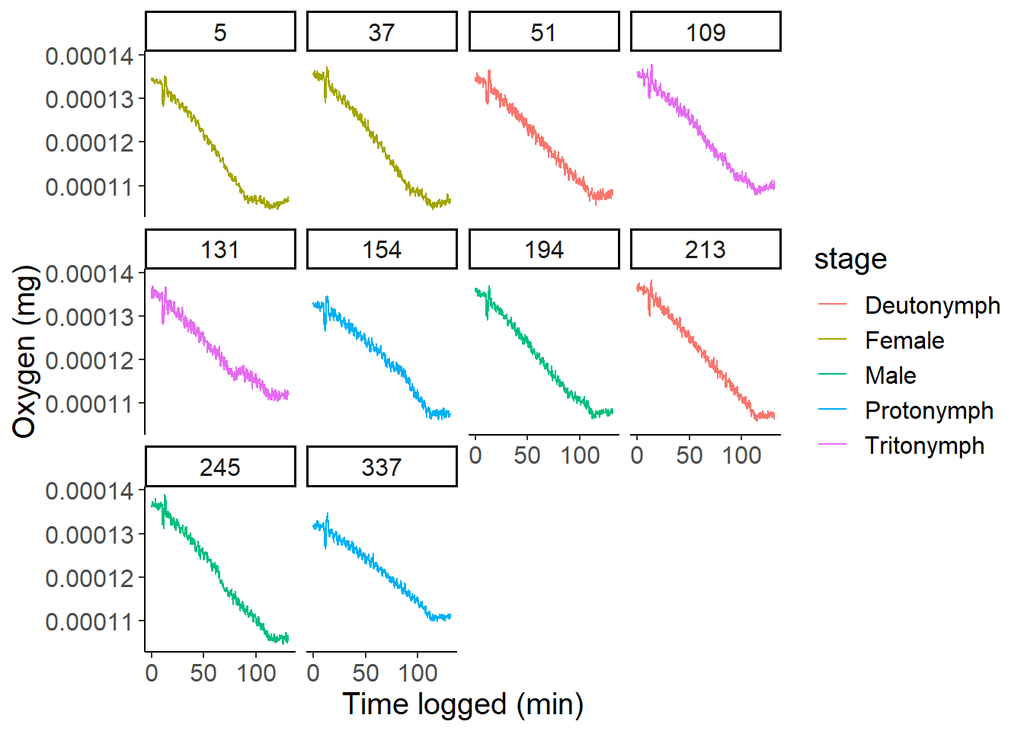

```r
ggplot(ox4, aes(x=logtime, y=oxymg,group=ind, color=stage))+ #MODIFY FOR EACH TRIAL
  geom_line()+
  theme_classic()+
  theme(text = element_text(size = 15))+
  #ylim(8,12) +
  facet_wrap(~ind)+
  xlab("Time logged (min)")+
  ylab("Oxygen (mg)")
```

### 3.2.4 Trial 5

```r
# creating vector for columns names
cnames<-c("date", "time", "logtime", "oxygen", "phase", "amplitude", "temperature")

# creating vector for path
path<-"Data/Oxygen/Trial 5/" #MODIFY FOR EEACH TRIAL

# Creating list of file names
list <- list.files(path = path, pattern=".*txt") # creates the list of all the txt files in the directory

# Renaming files to remove the "-"
newname <- sub('-','', list) ## new name
file.rename(file.path(path,list), file.path(path, newname)) ## renaming it.
```

```
##  [1] TRUE TRUE TRUE TRUE TRUE TRUE TRUE TRUE TRUE TRUE
```

```r
# Creating list of file names again
list <- list.files(path = path, pattern=".*txt") # creates the list of all the txt files in the directory

#Reading all files at once
for (i in list) {
  filename <- paste0( "frame",sub(pattern = "(.*)\\..*$", replacement = "\\1", basename(i)))
  wd <- paste0(path, i)
  assign(filename, read.delim2(wd,sep=";", skip=38, header=F, col.names=cnames)) #CHECK FOR EACH TRIALS IF THE SAME NUMBRE OF ROWS APPLIES

}


# Merging all into a single table
pattern<-grep("framepstrial5",names(.GlobalEnv),value=TRUE) #MODIFY FOR EACH TRIAL
list2<-do.call("list",mget(pattern))

t5a<-bind_rows(list2, .id="id") #MODIFY FOR EACH TRIAL


# Adding and modifying data to phase files
t5b<-t5a %>% #MODIFY FOR EACH TRIAL
  select(c("id", "date", "time", "logtime", "phase")) %>%
  mutate(trial=5,#MODIFY FOR EACH TRIAL
         date=mdy(date), #formatting date
         datetime=paste0(date," ", time), #copying date and time together
         datetime=as_datetime(datetime, format="%Y-%m-%d %I:%M:%S %p")-minutes(9), #adjusting pc time to real time
         datetime2=round_date(datetime, unit="minute"),
         channel=case_when(str_detect(id, "ch10")~10, # Assigning channels
                       str_detect(id, "ch1")~1,
                       str_detect(id, "ch2")~2,
                       str_detect(id, "ch3")~3,
                       str_detect(id, "ch4")~4,
                       str_detect(id, "ch5")~5,
                       str_detect(id, "ch6")~6,
                       str_detect(id, "ch7")~7,
                       str_detect(id, "ch8")~8,
                       str_detect(id, "ch9")~9,
                       TRUE~0),
         ind=case_when(str_detect(id, "ch10")~324, # Assigning individuals MODIFY FOR EACH TRIAL
                       str_detect(id, "ch1")~024,
                       str_detect(id, "ch2")~253,
                       str_detect(id, "ch3")~025,
                       str_detect(id, "ch4")~003,
                       str_detect(id, "ch5")~290,
                       str_detect(id, "ch6")~244,
                       str_detect(id, "ch7")~257,
                       str_detect(id, "ch8")~032,
                       str_detect(id, "ch9")~159,
                       TRUE~0),
         stage=case_when(str_detect(id, "ch10")~"Protonymph",#Assigning stage MODIFY FOR EACH TRIAL
                       str_detect(id, "ch1")~"Female",
                         str_detect(id, "ch2")~"Male",
                       str_detect(id, "ch3")~"Tritonymph",
                       str_detect(id, "ch4")~"Deutonymph",
                       str_detect(id, "ch5")~"Protonymph",
                       str_detect(id, "ch6")~"Female",
                       str_detect(id, "ch7")~"Male",
                       str_detect(id, "ch8")~"Tritonymph",
                       #str_detect(id, "ch9")~"Male",
                       TRUE~"Deutonymph"),
         weight=case_when(str_detect(id, "ch10")~0.158, # Assigning weights MODIFY FOR EACH TRIAL
                       str_detect(id, "ch1")~1.472,
                       str_detect(id, "ch2")~0.900,
                       str_detect(id, "ch3")~0.688,
                       str_detect(id, "ch4")~0.328,
                       str_detect(id, "ch5")~0.166,
                       str_detect(id, "ch6")~1.454,
                       str_detect(id, "ch7")~0.946,
                       str_detect(id, "ch8")~0.613,
                       #str_detect(id, "ch9")~1.001,
                       TRUE~0.278),
         atm=round(33.864*28.84)) #MODIFY FOR EACH TRIAL: 33.864 * pressure in inHg

# Getting temperature for this trial
temp2<-all_corr %>%
  filter(trial==5) %>% #MODIFY FOR EACH TRIAL
  select(c("datetime2","datetime", "tempcorr", "ramp"))

#Merging phase and temperature data
t5<- full_join(t5b, temp2, by="datetime2", suffix=c("",".temp")) #MODIFY FOR EACH TRIAL


head(t5) #MODIFY FOR EACH TRIAL
```

|  | id | date | time | logtime | phase | trial | datetime | datetime2 | channel | ind | stage | weight | atm | datetime.temp | tempcorr | ramp |
| --- | --- | --- | --- | --- | --- | --- | --- | --- | --- | --- | --- | --- | --- | --- | --- | --- |
| 1 | framepstrial5ch10 | 2022-06-22 | 2:20:23 PM | 0.00 | 26.730 | 5 | 2022-06-22 14:11:23 | 2022-06-22 14:11:00 | 10 | 324 | Protonymph | 0.158 | 977 | 2022-06-22 14:10:44 | 29.78125 | 0.255547 |
| 2 | framepstrial5ch10 | 2022-06-22 | 2:20:23 PM | 0.00 | 26.730 | 5 | 2022-06-22 14:11:23 | 2022-06-22 14:11:00 | 10 | 324 | Protonymph | 0.158 | 977 | 2022-06-22 14:11:14 | 29.75398 | 0.255547 |
| 3 | framepstrial5ch10 | 2022-06-22 | 2:20:25 PM | 0.03 | 26.740 | 5 | 2022-06-22 14:11:25 | 2022-06-22 14:11:00 | 10 | 324 | Protonymph | 0.158 | 977 | 2022-06-22 14:10:44 | 29.78125 | 0.255547 |
| 4 | framepstrial5ch10 | 2022-06-22 | 2:20:25 PM | 0.03 | 26.740 | 5 | 2022-06-22 14:11:25 | 2022-06-22 14:11:00 | 10 | 324 | Protonymph | 0.158 | 977 | 2022-06-22 14:11:14 | 29.75398 | 0.255547 |
| 5 | framepstrial5ch10 | 2022-06-22 | 2:20:38 PM | 0.24 | 26.820 | 5 | 2022-06-22 14:11:38 | 2022-06-22 14:12:00 | 10 | 324 | Protonymph | 0.158 | 977 | 2022-06-22 14:11:44 | 29.83687 | 0.255547 |
| 6 | framepstrial5ch10 | 2022-06-22 | 2:20:38 PM | 0.24 | 26.820 | 5 | 2022-06-22 14:11:38 | 2022-06-22 14:12:00 | 10 | 324 | Protonymph | 0.158 | 977 | 2022-06-22 14:12:14 | 29.95956 | 0.255547 |

```r
#Estimating Oxygen
f<-pi/180
f
```

```
## [1] 0.01745329
```

```r
ox5<-t5 %>% #MODIFY FOR EACH TRIAL
  na.omit() %>%
  mutate(phase=as.numeric(phase),
         ind=as.factor(ind),
         logtime=as.numeric(logtime),
         phaseangle=62.14-0.08915*tempcorr,
         sternvolmer=0.04899+4.965*10^(-4)*tempcorr,
         bunsen=(48.998-1.335*tempcorr+2.755*10^(-2)*tempcorr^2-3.22*10^(-4)*tempcorr^3+1.598*10^(-6)*tempcorr^4)*10^(-3),
         tempK=tempcorr+273,
         watervapor=exp(52.57-(6690.9/tempK)-4.681*log(tempK)),
         oxysat=(tan((pi/180)*phaseangle)-tan((pi/180)*phase))/tan((pi/180)*phase)*sternvolmer,
         oxymgl=(atm-watervapor)/1013*oxysat*0.2095*bunsen*1000*(32/22.414)*10,
         oxymg=oxymgl*volume)

head(ox5) #MODIFY FOR EACH TRIAL
```

|  | id | date | time | logtime | phase | trial | datetime | datetime2 | channel | ind | stage | weight | atm | datetime.temp | tempcorr | ramp | phaseangle | sternvolmer | bunsen | tempK | watervapor | oxysat | oxymgl | oxymg |
| --- | --- | --- | --- | --- | --- | --- | --- | --- | --- | --- | --- | --- | --- | --- | --- | --- | --- | --- | --- | --- | --- | --- | --- | --- |
| 1 | framepstrial5ch10 | 2022-06-22 | 2:20:23 PM | 0.00 | 26.73 | 5 | 2022-06-22 14:11:23 | 2022-06-22 14:11:00 | 10 | 324 | Protonymph | 0.158 | 977 | 2022-06-22 14:10:44 | 29.78125 | 0.255547 | 59.48500 | 0.06377639 | 0.02642659 | 302.7812 | 41.64850 | 0.1510870 | 11.02677 | 0.0001385665 |
| 2 | framepstrial5ch10 | 2022-06-22 | 2:20:23 PM | 0.00 | 26.73 | 5 | 2022-06-22 14:11:23 | 2022-06-22 14:11:00 | 10 | 324 | Protonymph | 0.158 | 977 | 2022-06-22 14:11:14 | 29.75398 | 0.255547 | 59.48743 | 0.06376285 | 0.02643701 | 302.7540 | 41.58322 | 0.1510758 | 11.03107 | 0.0001386205 |
| 3 | framepstrial5ch10 | 2022-06-22 | 2:20:25 PM | 0.03 | 26.74 | 5 | 2022-06-22 14:11:25 | 2022-06-22 14:11:00 | 10 | 324 | Protonymph | 0.158 | 977 | 2022-06-22 14:10:44 | 29.78125 | 0.255547 | 59.48500 | 0.06377639 | 0.02642659 | 302.7812 | 41.64850 | 0.1509937 | 11.01996 | 0.0001384809 |
| 4 | framepstrial5ch10 | 2022-06-22 | 2:20:25 PM | 0.03 | 26.74 | 5 | 2022-06-22 14:11:25 | 2022-06-22 14:11:00 | 10 | 324 | Protonymph | 0.158 | 977 | 2022-06-22 14:11:14 | 29.75398 | 0.255547 | 59.48743 | 0.06376285 | 0.02643701 | 302.7540 | 41.58322 | 0.1509825 | 11.02426 | 0.0001385349 |
| 5 | framepstrial5ch10 | 2022-06-22 | 2:20:38 PM | 0.24 | 26.82 | 5 | 2022-06-22 14:11:38 | 2022-06-22 14:12:00 | 10 | 324 | Protonymph | 0.158 | 977 | 2022-06-22 14:11:44 | 29.83687 | 0.255547 | 59.48004 | 0.06380400 | 0.02640537 | 302.8369 | 41.78193 | 0.1502722 | 10.95693 | 0.0001376889 |
| 6 | framepstrial5ch10 | 2022-06-22 | 2:20:38 PM | 0.24 | 26.82 | 5 | 2022-06-22 14:11:38 | 2022-06-22 14:12:00 | 10 | 324 | Protonymph | 0.158 | 977 | 2022-06-22 14:12:14 | 29.95956 | 0.255547 | 59.46911 | 0.06386492 | 0.02635871 | 302.9596 | 42.07760 | 0.1503222 | 10.93775 | 0.0001374478 |

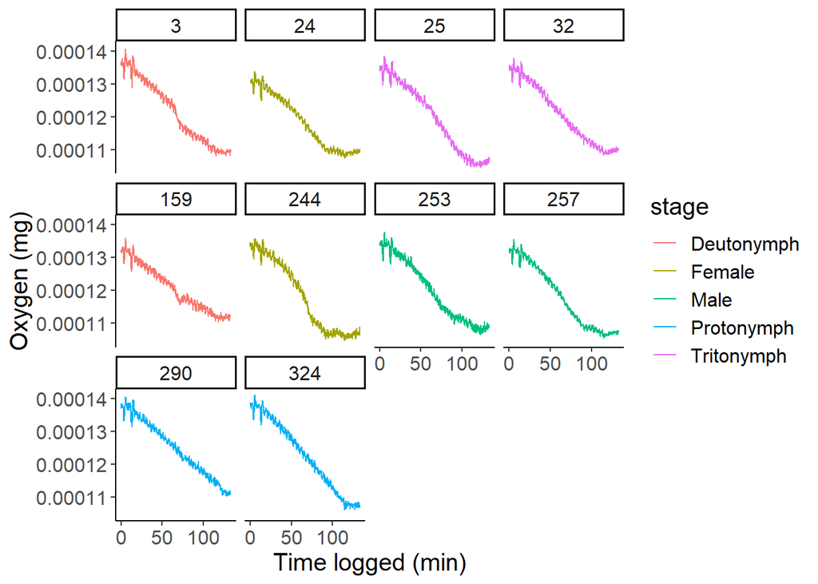

```r
ggplot(ox5, aes(x=logtime, y=oxymg,group=ind, color=stage))+ #MODIFY FOR EACH TRIAL
  geom_line()+
  theme_classic()+
  theme(text = element_text(size = 15))+
  #ylim(8,12) +
  facet_wrap(~ind)+
  xlab("Time logged (min)")+
  ylab("Oxygen (mg)")
```

### 3.2.5 Trial 6

```r
# creating vector for columns names
cnames<-c("date", "time", "logtime", "oxygen", "phase", "amplitude", "temperature")

# creating vector for path
path<-"Data/Oxygen/Trial 6/" #MODIFY FOR EEACH TRIAL

# Creating list of file names
list <- list.files(path = path, pattern=".*txt") # creates the list of all the txt files in the directory

# Renaming files to remove the "-"
newname <- sub('-','', list) ## new name
file.rename(file.path(path,list), file.path(path, newname)) ## renaming it.
```

```
##  [1] TRUE TRUE TRUE TRUE TRUE TRUE TRUE TRUE TRUE TRUE
```

```r
# Creating list of file names again
list <- list.files(path = path, pattern=".*txt") # creates the list of all the txt files in the directory

#Reading all files at once
for (i in list) {
  filename <- paste0( "frame",sub(pattern = "(.*)\\..*$", replacement = "\\1", basename(i)))
  wd <- paste0(path, i)
  assign(filename, read.delim2(wd,sep=";", skip=38, header=F, col.names=cnames)) #CHECK FOR EACH TRIALS IF THE SAME NUMBRE OF ROWS APPLIES

}


# Merging all into a single table
pattern<-grep("framepstrial6",names(.GlobalEnv),value=TRUE) #MODIFY FOR EACH TRIAL
list2<-do.call("list",mget(pattern))

t6a<-bind_rows(list2, .id="id") #MODIFY FOR EACH TRIAL


# Adding and modifying data to phase files
t6b<-t6a %>% #MODIFY FOR EACH TRIAL
  select(c("id", "date", "time", "logtime", "phase")) %>%
  mutate(trial=6,#MODIFY FOR EACH TRIAL
         date=mdy(date), #formatting date
         datetime=paste0(date," ", time), #copying date and time together
         datetime=as_datetime(datetime, format="%Y-%m-%d %I:%M:%S %p")-minutes(9), #adjusting pc time to real time
         datetime2=round_date(datetime, unit="minute"),
         channel=case_when(str_detect(id, "ch10")~10, # Assigning channels
                       str_detect(id, "ch1")~1,
                       str_detect(id, "ch2")~2,
                       str_detect(id, "ch3")~3,
                       str_detect(id, "ch4")~4,
                       str_detect(id, "ch5")~5,
                       str_detect(id, "ch6")~6,
                       str_detect(id, "ch7")~7,
                       str_detect(id, "ch8")~8,
                       str_detect(id, "ch9")~9,
                       TRUE~0),
         ind=case_when(str_detect(id, "ch10")~267, # Assigning individuals MODIFY FOR EACH TRIAL
                       str_detect(id, "ch1")~288,
                       str_detect(id, "ch2")~030,
                       str_detect(id, "ch3")~1000,
                       str_detect(id, "ch4")~287,
                       str_detect(id, "ch5")~218,
                       str_detect(id, "ch6")~238,
                       str_detect(id, "ch7")~165,
                       str_detect(id, "ch8")~298,
                       str_detect(id, "ch9")~066,
                       TRUE~0),
         stage=case_when(str_detect(id, "ch10")~"Deutonymph",#Assigning stage MODIFY FOR EACH TRIAL
                       str_detect(id, "ch1")~"Deutonymph",
                         str_detect(id, "ch2")~"Female",
                       str_detect(id, "ch3")~"NA",
                       str_detect(id, "ch4")~"Tritonymph",
                       str_detect(id, "ch5")~"Tritonymph",
                       str_detect(id, "ch6")~"Male",
                       str_detect(id, "ch7")~"Protonymph",
                       str_detect(id, "ch8")~"Protonymph",
                       #str_detect(id, "ch9")~"Male",
                       TRUE~"Female"),
         weight=case_when(str_detect(id, "ch10")~0.221, # Assigning weights MODIFY FOR EACH TRIAL
                       str_detect(id, "ch1")~0.257,
                       str_detect(id, "ch2")~1.583,
                       str_detect(id, "ch3")~1000,
                       str_detect(id, "ch4")~0.583,
                       str_detect(id, "ch5")~0.715,
                       str_detect(id, "ch6")~0.794,
                       str_detect(id, "ch7")~0.142,
                       str_detect(id, "ch8")~0.201,
                       #str_detect(id, "ch9")~1.001,
                       TRUE~2.208),
         atm=round(33.864*28.81)) #MODIFY FOR EACH TRIAL: 33.864 * pressure in inHg

# Getting temperature for this trial
temp2<-all_corr %>%
  filter(trial==6) %>% #MODIFY FOR EACH TRIAL
  select(c("datetime2","datetime", "tempcorr", "ramp"))

#Merging phase and temperature data
t6<- full_join(t6b, temp2, by="datetime2", suffix=c("",".temp")) #MODIFY FOR EACH TRIAL


head(t6) #MODIFY FOR EACH TRIAL
```

|  | id | date | time | logtime | phase | trial | datetime | datetime2 | channel | ind | stage | weight | atm | datetime.temp | tempcorr | ramp |
| --- | --- | --- | --- | --- | --- | --- | --- | --- | --- | --- | --- | --- | --- | --- | --- | --- |
| 1 | framepstrial6ch1 | 2022-06-22 | 5:36:07 PM | 0.00 | 27.390 | 6 | 2022-06-22 17:27:07 | 2022-06-22 17:27:00 | 1 | 288 | Deutonymph | 0.257 | 976 | 2022-06-22 17:26:44 | 29.82269 | 0.2460939 |
| 2 | framepstrial6ch1 | 2022-06-22 | 5:36:07 PM | 0.00 | 27.390 | 6 | 2022-06-22 17:27:07 | 2022-06-22 17:27:00 | 1 | 288 | Deutonymph | 0.257 | 976 | 2022-06-22 17:27:14 | 29.89085 | 0.2460939 |
| 3 | framepstrial6ch1 | 2022-06-22 | 5:36:22 PM | 0.25 | 27.440 | 6 | 2022-06-22 17:27:22 | 2022-06-22 17:27:00 | 1 | 288 | Deutonymph | 0.257 | 976 | 2022-06-22 17:26:44 | 29.82269 | 0.2460939 |
| 4 | framepstrial6ch1 | 2022-06-22 | 5:36:22 PM | 0.25 | 27.440 | 6 | 2022-06-22 17:27:22 | 2022-06-22 17:27:00 | 1 | 288 | Deutonymph | 0.257 | 976 | 2022-06-22 17:27:14 | 29.89085 | 0.2460939 |
| 5 | framepstrial6ch1 | 2022-06-22 | 5:36:37 PM | 0.50 | 27.420 | 6 | 2022-06-22 17:27:37 | 2022-06-22 17:28:00 | 1 | 288 | Deutonymph | 0.257 | 976 | 2022-06-22 17:27:44 | 29.97319 | 0.2460939 |
| 6 | framepstrial6ch1 | 2022-06-22 | 5:36:37 PM | 0.50 | 27.420 | 6 | 2022-06-22 17:27:37 | 2022-06-22 17:28:00 | 1 | 288 | Deutonymph | 0.257 | 976 | 2022-06-22 17:28:14 | 29.93175 | 0.2460939 |

```r
#Estimating Oxygen
f<-pi/180
f
```

```
## [1] 0.01745329
```

```r
ox6<-t6 %>% #MODIFY FOR EACH TRIAL
  na.omit() %>%
  filter(ind < 900) %>%
  mutate(phase=as.numeric(phase),
         ind=as.factor(ind),
         logtime=as.numeric(logtime),
         phaseangle=62.14-0.08915*tempcorr,
         sternvolmer=0.04899+4.965*10^(-4)*tempcorr,
         bunsen=(48.998-1.335*tempcorr+2.755*10^(-2)*tempcorr^2-3.22*10^(-4)*tempcorr^3+1.598*10^(-6)*tempcorr^4)*10^(-3),
         tempK=tempcorr+273,
         watervapor=exp(52.57-(6690.9/tempK)-4.681*log(tempK)),
         oxysat=(tan((pi/180)*phaseangle)-tan((pi/180)*phase))/tan((pi/180)*phase)*sternvolmer,
         oxymgl=(atm-watervapor)/1013*oxysat*0.2095*bunsen*1000*(32/22.414)*10,
         oxymg=oxymgl*volume)

head(ox6) #MODIFY FOR EACH TRIAL
```

|  | id | date | time | logtime | phase | trial | datetime | datetime2 | channel | ind | stage | weight | atm | datetime.temp | tempcorr | ramp | phaseangle | sternvolmer | bunsen | tempK | watervapor | oxysat | oxymgl | oxymg |
| --- | --- | --- | --- | --- | --- | --- | --- | --- | --- | --- | --- | --- | --- | --- | --- | --- | --- | --- | --- | --- | --- | --- | --- | --- |
| 1 | framepstrial6ch1 | 2022-06-22 | 5:36:07 PM | 0.00 | 27.39 | 6 | 2022-06-22 17:27:07 | 2022-06-22 17:27:00 | 1 | 288 | Deutonymph | 0.257 | 976 | 2022-06-22 17:26:44 | 29.82269 | 0.2460939 | 59.48131 | 0.06379696 | 0.02641078 | 302.8227 | 41.74789 | 0.1450794 | 10.56955 | 0.0001328208 |
| 2 | framepstrial6ch1 | 2022-06-22 | 5:36:07 PM | 0.00 | 27.39 | 6 | 2022-06-22 17:27:07 | 2022-06-22 17:27:00 | 1 | 288 | Deutonymph | 0.257 | 976 | 2022-06-22 17:27:14 | 29.89085 | 0.2460939 | 59.47523 | 0.06383081 | 0.02638481 | 302.8908 | 41.91180 | 0.1451057 | 10.55922 | 0.0001326910 |
| 3 | framepstrial6ch1 | 2022-06-22 | 5:36:22 PM | 0.25 | 27.44 | 6 | 2022-06-22 17:27:22 | 2022-06-22 17:27:00 | 1 | 288 | Deutonymph | 0.257 | 976 | 2022-06-22 17:26:44 | 29.82269 | 0.2460939 | 59.48131 | 0.06379696 | 0.02641078 | 302.8227 | 41.74789 | 0.1446339 | 10.53709 | 0.0001324130 |
| 4 | framepstrial6ch1 | 2022-06-22 | 5:36:22 PM | 0.25 | 27.44 | 6 | 2022-06-22 17:27:22 | 2022-06-22 17:27:00 | 1 | 288 | Deutonymph | 0.257 | 976 | 2022-06-22 17:27:14 | 29.89085 | 0.2460939 | 59.47523 | 0.06383081 | 0.02638481 | 302.8908 | 41.91180 | 0.1446601 | 10.52679 | 0.0001322835 |
| 5 | framepstrial6ch1 | 2022-06-22 | 5:36:37 PM | 0.50 | 27.42 | 6 | 2022-06-22 17:27:37 | 2022-06-22 17:28:00 | 1 | 288 | Deutonymph | 0.257 | 976 | 2022-06-22 17:27:44 | 29.97319 | 0.2460939 | 59.46789 | 0.06387169 | 0.02635354 | 302.9732 | 42.11056 | 0.1448698 | 10.52731 | 0.0001322901 |
| 6 | framepstrial6ch1 | 2022-06-22 | 5:36:37 PM | 0.50 | 27.42 | 6 | 2022-06-22 17:27:37 | 2022-06-22 17:28:00 | 1 | 288 | Deutonymph | 0.257 | 976 | 2022-06-22 17:28:14 | 29.93175 | 0.2460939 | 59.47158 | 0.06385111 | 0.02636927 | 302.9317 | 42.01042 | 0.1448539 | 10.53357 | 0.0001323687 |

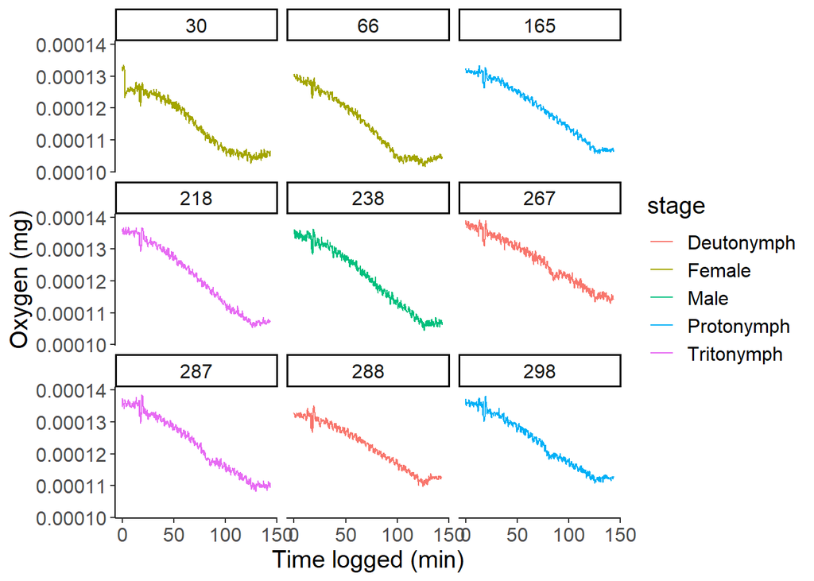

```r
ggplot(ox6, aes(x=logtime, y=oxymg,group=ind, color=stage))+ #MODIFY FOR EACH TRIAL
  geom_line()+
  theme_classic()+
  theme(text = element_text(size = 15))+
 # ylim(8,12) +
  facet_wrap(~ind)+
  xlab("Time logged (min)")+
  ylab("Oxygen (mg)")
```

### 3.2.6 Trial 7

```r
# creating vector for columns names
cnames<-c("date", "time", "logtime", "oxygen", "phase", "amplitude", "temperature")

# creating vector for path
path<-"Data/Oxygen/Trial 7/" #MODIFY FOR EEACH TRIAL

# Creating list of file names
list <- list.files(path = path, pattern=".*txt") # creates the list of all the txt files in the directory

# Renaming files to remove the "-"
newname <- sub('-','', list) ## new name
file.rename(file.path(path,list), file.path(path, newname)) ## renaming it.
```

```
##  [1] TRUE TRUE TRUE TRUE TRUE TRUE TRUE TRUE TRUE TRUE
```

```r
# Creating list of file names again
list <- list.files(path = path, pattern=".*txt") # creates the list of all the txt files in the directory

#Reading all files at once
for (i in list) {
  filename <- paste0( "frame",sub(pattern = "(.*)\\..*$", replacement = "\\1", basename(i)))
  wd <- paste0(path, i)
  assign(filename, read.delim2(wd,sep=";", skip=38, header=F, col.names=cnames)) #CHECK FOR EACH TRIALS IF THE SAME NUMBRE OF ROWS APPLIES

}


# Merging all into a single table
pattern<-grep("framepstrial7",names(.GlobalEnv),value=TRUE) #MODIFY FOR EACH TRIAL
list2<-do.call("list",mget(pattern))

t7a<-bind_rows(list2, .id="id") #MODIFY FOR EACH TRIAL


# Adding and modifying data to phase files
t7b<-t7a %>% #MODIFY FOR EACH TRIAL
  select(c("id", "date", "time", "logtime", "phase")) %>%
  mutate(trial=7,#MODIFY FOR EACH TRIAL
         date=mdy(date), #formatting date
         datetime=paste0(date," ", time), #copying date and time together
         datetime=as_datetime(datetime, format="%Y-%m-%d %I:%M:%S %p")-minutes(9), #adjusting pc time to real time
         datetime2=round_date(datetime, unit="minute"),
         channel=case_when(str_detect(id, "ch10")~10, # Assigning channels
                       str_detect(id, "ch1")~1,
                       str_detect(id, "ch2")~2,
                       str_detect(id, "ch3")~3,
                       str_detect(id, "ch4")~4,
                       str_detect(id, "ch5")~5,
                       str_detect(id, "ch6")~6,
                       str_detect(id, "ch7")~7,
                       str_detect(id, "ch8")~8,
                       str_detect(id, "ch9")~9,
                       TRUE~0),
         ind=case_when(str_detect(id, "ch10")~274, # Assigning individuals MODIFY FOR EACH TRIAL
                       str_detect(id, "ch1")~235,
                       str_detect(id, "ch2")~216,
                       str_detect(id, "ch3")~1000,
                       str_detect(id, "ch4")~237,
                       str_detect(id, "ch5")~175,
                       str_detect(id, "ch6")~246,
                       str_detect(id, "ch7")~232,
                       str_detect(id, "ch8")~269,
                       str_detect(id, "ch9")~043,
                       TRUE~0),
         stage=case_when(str_detect(id, "ch10")~"Deutonymph",#Assigning stage MODIFY FOR EACH TRIAL
                       str_detect(id, "ch1")~"Male",
                         str_detect(id, "ch2")~"Male",
                       str_detect(id, "ch3")~"NA",
                       str_detect(id, "ch4")~"Female",
                       str_detect(id, "ch5")~"Protonymph",
                       str_detect(id, "ch6")~"Female",
                       str_detect(id, "ch7")~"Tritonymph",
                       str_detect(id, "ch8")~"Tritonymph",
                       #str_detect(id, "ch9")~"Male",
                       TRUE~"Protonymph"),
         weight=case_when(str_detect(id, "ch10")~0.324, # Assigning weights MODIFY FOR EACH TRIAL
                       str_detect(id, "ch1")~0.900,
                       str_detect(id, "ch2")~1.126,
                       str_detect(id, "ch3")~1000,
                       str_detect(id, "ch4")~1.345,
                       str_detect(id, "ch5")~0.213,
                       str_detect(id, "ch6")~1.937,
                       str_detect(id, "ch7")~0.748,
                       str_detect(id, "ch8")~0.622,
                       #str_detect(id, "ch9")~1.001,
                       TRUE~0.139),
         atm=round(33.864*28.78)) #MODIFY FOR EACH TRIAL: 33.864 * pressure in inHg

# Getting temperature for this trial
temp2<-all_corr %>%
  filter(trial==7) %>% #MODIFY FOR EACH TRIAL
  select(c("datetime2","datetime", "tempcorr", "ramp"))

#Merging phase and temperature data
t7<- full_join(t7b, temp2, by="datetime2", suffix=c("",".temp")) #MODIFY FOR EACH TRIAL


head(t7) #MODIFY FOR EACH TRIAL
```

|  | id | date | time | logtime | phase | trial | datetime | datetime2 | channel | ind | stage | weight | atm | datetime.temp | tempcorr | ramp |
| --- | --- | --- | --- | --- | --- | --- | --- | --- | --- | --- | --- | --- | --- | --- | --- | --- |
| 1 | framepstrial7ch10 | 2022-06-22 | 8:33:27 PM | 0.00 | 26.680 | 7 | 2022-06-22 20:24:27 | 2022-06-22 20:24:00 | 10 | 274 | Deutonymph | 0.324 | 975 | 2022-06-22 20:23:44 | 29.89085 | 0.2570457 |
| 2 | framepstrial7ch10 | 2022-06-22 | 8:33:27 PM | 0.00 | 26.680 | 7 | 2022-06-22 20:24:27 | 2022-06-22 20:24:00 | 10 | 274 | Deutonymph | 0.324 | 975 | 2022-06-22 20:24:14 | 29.83632 | 0.2570457 |
| 3 | framepstrial7ch10 | 2022-06-22 | 8:33:36 PM | 0.14 | 26.750 | 7 | 2022-06-22 20:24:36 | 2022-06-22 20:25:00 | 10 | 274 | Deutonymph | 0.324 | 975 | 2022-06-22 20:24:44 | 29.90448 | 0.2570457 |
| 4 | framepstrial7ch10 | 2022-06-22 | 8:33:36 PM | 0.14 | 26.750 | 7 | 2022-06-22 20:24:36 | 2022-06-22 20:25:00 | 10 | 274 | Deutonymph | 0.324 | 975 | 2022-06-22 20:25:14 | 29.94592 | 0.2570457 |
| 5 | framepstrial7ch10 | 2022-06-22 | 8:33:51 PM | 0.39 | 26.740 | 7 | 2022-06-22 20:24:51 | 2022-06-22 20:25:00 | 10 | 274 | Deutonymph | 0.324 | 975 | 2022-06-22 20:24:44 | 29.90448 | 0.2570457 |
| 6 | framepstrial7ch10 | 2022-06-22 | 8:33:51 PM | 0.39 | 26.740 | 7 | 2022-06-22 20:24:51 | 2022-06-22 20:25:00 | 10 | 274 | Deutonymph | 0.324 | 975 | 2022-06-22 20:25:14 | 29.94592 | 0.2570457 |

```r
#Estimating Oxygen
f<-pi/180
f
```

```
## [1] 0.01745329
```

```r
ox7<-t7 %>% #MODIFY FOR EACH TRIAL
  na.omit() %>%
  filter(ind < 900) %>%
  mutate(phase=as.numeric(phase),
         ind=as.factor(ind),
         logtime=as.numeric(logtime),
         phaseangle=62.14-0.08915*tempcorr,
         sternvolmer=0.04899+4.965*10^(-4)*tempcorr,
         bunsen=(48.998-1.335*tempcorr+2.755*10^(-2)*tempcorr^2-3.22*10^(-4)*tempcorr^3+1.598*10^(-6)*tempcorr^4)*10^(-3),
         tempK=tempcorr+273,
         watervapor=exp(52.57-(6690.9/tempK)-4.681*log(tempK)),
         oxysat=(tan((pi/180)*phaseangle)-tan((pi/180)*phase))/tan((pi/180)*phase)*sternvolmer,
         oxymgl=(atm-watervapor)/1013*oxysat*0.2095*bunsen*1000*(32/22.414)*10,
         oxymg=oxymgl*volume)

head(ox7) #MODIFY FOR EACH TRIAL
```

|  | id | date | time | logtime | phase | trial | datetime | datetime2 | channel | ind | stage | weight | atm | datetime.temp | tempcorr | ramp | phaseangle | sternvolmer | bunsen | tempK | watervapor | oxysat | oxymgl | oxymg |
| --- | --- | --- | --- | --- | --- | --- | --- | --- | --- | --- | --- | --- | --- | --- | --- | --- | --- | --- | --- | --- | --- | --- | --- | --- |
| 1 | framepstrial7ch10 | 2022-06-22 | 8:33:27 PM | 0.00 | 26.68 | 7 | 2022-06-22 20:24:27 | 2022-06-22 20:24:00 | 10 | 274 | Deutonymph | 0.324 | 975 | 2022-06-22 20:23:44 | 29.89085 | 0.2570457 | 59.47523 | 0.06383081 | 0.02638481 | 302.8908 | 41.91180 | 0.1515999 | 11.01998 | 0.0001384812 |
| 2 | framepstrial7ch10 | 2022-06-22 | 8:33:27 PM | 0.00 | 26.68 | 7 | 2022-06-22 20:24:27 | 2022-06-22 20:24:00 | 10 | 274 | Deutonymph | 0.324 | 975 | 2022-06-22 20:24:14 | 29.83632 | 0.2570457 | 59.48009 | 0.06380373 | 0.02640558 | 302.8363 | 41.78062 | 0.1515774 | 11.02857 | 0.0001385890 |
| 3 | framepstrial7ch10 | 2022-06-22 | 8:33:36 PM | 0.14 | 26.75 | 7 | 2022-06-22 20:24:36 | 2022-06-22 20:25:00 | 10 | 274 | Deutonymph | 0.324 | 975 | 2022-06-22 20:24:44 | 29.90448 | 0.2570457 | 59.47402 | 0.06383758 | 0.02637963 | 302.9045 | 41.94465 | 0.1509511 | 10.97027 | 0.0001378565 |
| 4 | framepstrial7ch10 | 2022-06-22 | 8:33:36 PM | 0.14 | 26.75 | 7 | 2022-06-22 20:24:36 | 2022-06-22 20:25:00 | 10 | 274 | Deutonymph | 0.324 | 975 | 2022-06-22 20:25:14 | 29.94592 | 0.2570457 | 59.47032 | 0.06385815 | 0.02636389 | 302.9459 | 42.04466 | 0.1509681 | 10.96379 | 0.0001377750 |
| 5 | framepstrial7ch10 | 2022-06-22 | 8:33:51 PM | 0.39 | 26.74 | 7 | 2022-06-22 20:24:51 | 2022-06-22 20:25:00 | 10 | 274 | Deutonymph | 0.324 | 975 | 2022-06-22 20:24:44 | 29.90448 | 0.2570457 | 59.47402 | 0.06383758 | 0.02637963 | 302.9045 | 41.94465 | 0.1510444 | 10.97706 | 0.0001379417 |
| 6 | framepstrial7ch10 | 2022-06-22 | 8:33:51 PM | 0.39 | 26.74 | 7 | 2022-06-22 20:24:51 | 2022-06-22 20:25:00 | 10 | 274 | Deutonymph | 0.324 | 975 | 2022-06-22 20:25:14 | 29.94592 | 0.2570457 | 59.47032 | 0.06385815 | 0.02636389 | 302.9459 | 42.04466 | 0.1510614 | 10.97056 | 0.0001378602 |

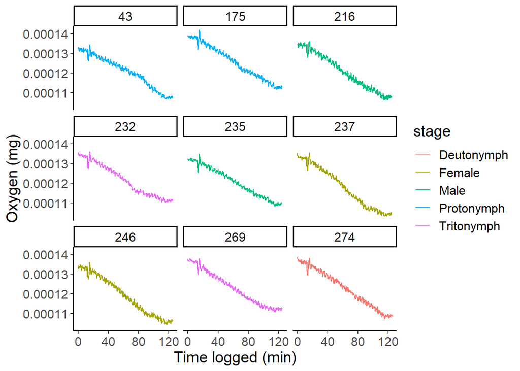

```r
ggplot(ox7, aes(x=logtime, y=oxymg,group=ind, color=stage))+ #MODIFY FOR EACH TRIAL
  geom_line()+
  theme_classic()+
  theme(text = element_text(size = 15))+
 # ylim(8,12) +
  facet_wrap(~ind)+
  xlab("Time logged (min)")+
  ylab("Oxygen (mg)")
```

### 3.2.7 Trial 8

```r
# creating vector for columns names
cnames<-c("date", "time", "logtime", "oxygen", "phase", "amplitude", "temperature")

# creating vector for path
path<-"Data/Oxygen/Trial 8/" #MODIFY FOR EEACH TRIAL

# Creating list of file names
list <- list.files(path = path, pattern=".*txt") # creates the list of all the txt files in the directory

# Renaming files to remove the "-"
newname <- sub('-','', list) ## new name
file.rename(file.path(path,list), file.path(path, newname)) ## renaming it.
```

```
##  [1] TRUE TRUE TRUE TRUE TRUE TRUE TRUE TRUE TRUE TRUE
```

```r
# Creating list of file names again
list <- list.files(path = path, pattern=".*txt") # creates the list of all the txt files in the directory

#Reading all files at once
for (i in list) {
  filename <- paste0( "frame",sub(pattern = "(.*)\\..*$", replacement = "\\1", basename(i)))
  wd <- paste0(path, i)
  assign(filename, read.delim2(wd,sep=";", skip=38, header=F, col.names=cnames)) #CHECK FOR EACH TRIALS IF THE SAME NUMBRE OF ROWS APPLIES

}


# Merging all into a single table
pattern<-grep("framepstrial8",names(.GlobalEnv),value=TRUE) #MODIFY FOR EACH TRIAL
list2<-do.call("list",mget(pattern))

t8a<-bind_rows(list2, .id="id") #MODIFY FOR EACH TRIAL


# Adding and modifying data to phase files
t8b<-t8a %>% #MODIFY FOR EACH TRIAL
  select(c("id", "date", "time", "logtime", "phase")) %>%
  mutate(trial=8,#MODIFY FOR EACH TRIAL
         date=mdy(date), #formatting date
         datetime=paste0(date," ", time), #copying date and time together
         datetime=as_datetime(datetime, format="%Y-%m-%d %I:%M:%S %p")-minutes(9), #adjusting pc time to real time
         datetime2=round_date(datetime, unit="minute"),
         channel=case_when(str_detect(id, "ch10")~10, # Assigning channels
                       str_detect(id, "ch1")~1,
                       str_detect(id, "ch2")~2,
                       str_detect(id, "ch3")~3,
                       str_detect(id, "ch4")~4,
                       str_detect(id, "ch5")~5,
                       str_detect(id, "ch6")~6,
                       str_detect(id, "ch7")~7,
                       str_detect(id, "ch8")~8,
                       str_detect(id, "ch9")~9,
                       TRUE~0),
         ind=case_when(str_detect(id, "ch10")~345, # Assigning individuals MODIFY FOR EACH TRIAL
                       str_detect(id, "ch1")~301,
                       str_detect(id, "ch2")~107,
                       str_detect(id, "ch3")~54,
                       str_detect(id, "ch4")~270,
                       str_detect(id, "ch5")~85,
                       str_detect(id, "ch6")~36,
                       str_detect(id, "ch7")~112,
                       str_detect(id, "ch8")~138,
                       str_detect(id, "ch9")~80,
                       TRUE~0),
         stage=case_when(str_detect(id, "ch10")~"Tritonymph",#Assigning stage MODIFY FOR EACH TRIAL
                       str_detect(id, "ch1")~"Protonymph",
                         str_detect(id, "ch2")~"Male",
                       str_detect(id, "ch3")~"Tritonymph",
                       str_detect(id, "ch4")~"Deutonymph",
                       str_detect(id, "ch5")~"Female",
                       str_detect(id, "ch6")~"Protonymph",
                       str_detect(id, "ch7")~"Female",
                       str_detect(id, "ch8")~"Deutonymph",
                       #str_detect(id, "ch9")~"Male",
                       TRUE~"Male"),
         weight=case_when(str_detect(id, "ch10")~0.863, # Assigning weights MODIFY FOR EACH TRIAL
                       str_detect(id, "ch1")~0.176,
                       str_detect(id, "ch2")~0.648,
                       str_detect(id, "ch3")~0.858,
                       str_detect(id, "ch4")~0.325,
                       str_detect(id, "ch5")~1.863,
                       str_detect(id, "ch6")~0.146,
                       str_detect(id, "ch7")~1.522,
                       str_detect(id, "ch8")~0.329,
                       #str_detect(id, "ch9")~1.001,
                       TRUE~1.199),
         atm=round(33.864*28.72)) #MODIFY FOR EACH TRIAL: 33.864 * pressure in inHg

# Getting temperature for this trial
temp2<-all_corr %>%
  filter(trial==8) %>% #MODIFY FOR EACH TRIAL
  select(c("datetime2","datetime", "tempcorr", "ramp"))

#Merging phase and temperature data
t8<- full_join(t8b, temp2, by="datetime2", suffix=c("",".temp")) #MODIFY FOR EACH TRIAL


head(t8) #MODIFY FOR EACH TRIAL
```

|  | id | date | time | logtime | phase | trial | datetime | datetime2 | channel | ind | stage | weight | atm | datetime.temp | tempcorr | ramp |
| --- | --- | --- | --- | --- | --- | --- | --- | --- | --- | --- | --- | --- | --- | --- | --- | --- |
| 1 | framepstrial8ch1 | 2022-06-23 | 9:44:58 AM | 0.00 | 27.440 | 8 | 2022-06-23 09:35:58 | 2022-06-23 09:36:00 | 1 | 301 | Protonymph | 0.176 | 973 |  | NA | NA |
| 2 | framepstrial8ch1 | 2022-06-23 | 9:45:13 AM | 0.25 | 27.470 | 8 | 2022-06-23 09:36:13 | 2022-06-23 09:36:00 | 1 | 301 | Protonymph | 0.176 | 973 |  | NA | NA |
| 3 | framepstrial8ch1 | 2022-06-23 | 9:45:28 AM | 0.50 | 27.530 | 8 | 2022-06-23 09:36:28 | 2022-06-23 09:36:00 | 1 | 301 | Protonymph | 0.176 | 973 |  | NA | NA |
| 4 | framepstrial8ch1 | 2022-06-23 | 9:45:43 AM | 0.75 | 27.490 | 8 | 2022-06-23 09:36:43 | 2022-06-23 09:37:00 | 1 | 301 | Protonymph | 0.176 | 973 | 2022-06-23 09:37:08 | 29.7687 | 0.25092 |
| 5 | framepstrial8ch1 | 2022-06-23 | 9:45:58 AM | 1.00 | 27.470 | 8 | 2022-06-23 09:36:58 | 2022-06-23 09:37:00 | 1 | 301 | Protonymph | 0.176 | 973 | 2022-06-23 09:37:08 | 29.7687 | 0.25092 |
| 6 | framepstrial8ch1 | 2022-06-23 | 9:46:13 AM | 1.25 | 27.530 | 8 | 2022-06-23 09:37:13 | 2022-06-23 09:37:00 | 1 | 301 | Protonymph | 0.176 | 973 | 2022-06-23 09:37:08 | 29.7687 | 0.25092 |

```r
#Estimating Oxygen
f<-pi/180
f
```

```
## [1] 0.01745329
```

```r
ox8<-t8 %>% #MODIFY FOR EACH TRIAL
  na.omit() %>%
  filter(ind < 900) %>%
  mutate(phase=as.numeric(phase),
         ind=as.factor(ind),
         logtime=as.numeric(logtime),
         phaseangle=62.14-0.08915*tempcorr,
         sternvolmer=0.04899+4.965*10^(-4)*tempcorr,
         bunsen=(48.998-1.335*tempcorr+2.755*10^(-2)*tempcorr^2-3.22*10^(-4)*tempcorr^3+1.598*10^(-6)*tempcorr^4)*10^(-3),
         tempK=tempcorr+273,
         watervapor=exp(52.57-(6690.9/tempK)-4.681*log(tempK)),
         oxysat=(tan((pi/180)*phaseangle)-tan((pi/180)*phase))/tan((pi/180)*phase)*sternvolmer,
         oxymgl=(atm-watervapor)/1013*oxysat*0.2095*bunsen*1000*(32/22.414)*10,
         oxymg=oxymgl*volume)

head(ox8) #MODIFY FOR EACH TRIAL
```

|  | id | date | time | logtime | phase | trial | datetime | datetime2 | channel | ind | stage | weight | atm | datetime.temp | tempcorr | ramp | phaseangle | sternvolmer | bunsen | tempK | watervapor | oxysat | oxymgl | oxymg |
| --- | --- | --- | --- | --- | --- | --- | --- | --- | --- | --- | --- | --- | --- | --- | --- | --- | --- | --- | --- | --- | --- | --- | --- | --- |
| 1 | framepstrial8ch1 | 2022-06-23 | 9:45:43 AM | 0.75 | 27.49 | 8 | 2022-06-23 09:36:43 | 2022-06-23 09:37:00 | 1 | 301 | Protonymph | 0.176 | 973 | 2022-06-23 09:37:08 | 29.76870 | 0.25092 | 59.48612 | 0.06377016 | 0.02643139 | 302.7687 | 41.61846 | 0.1441693 | 10.47914 | 0.0001316847 |
| 2 | framepstrial8ch1 | 2022-06-23 | 9:45:58 AM | 1.00 | 27.47 | 8 | 2022-06-23 09:36:58 | 2022-06-23 09:37:00 | 1 | 301 | Protonymph | 0.176 | 973 | 2022-06-23 09:37:08 | 29.76870 | 0.25092 | 59.48612 | 0.06377016 | 0.02643139 | 302.7687 | 41.61846 | 0.1443467 | 10.49203 | 0.0001318467 |
| 3 | framepstrial8ch1 | 2022-06-23 | 9:46:13 AM | 1.25 | 27.53 | 8 | 2022-06-23 09:37:13 | 2022-06-23 09:37:00 | 1 | 301 | Protonymph | 0.176 | 973 | 2022-06-23 09:37:08 | 29.76870 | 0.25092 | 59.48612 | 0.06377016 | 0.02643139 | 302.7687 | 41.61846 | 0.1438152 | 10.45340 | 0.0001313613 |
| 4 | framepstrial8ch1 | 2022-06-23 | 9:46:28 AM | 1.50 | 27.46 | 8 | 2022-06-23 09:37:28 | 2022-06-23 09:37:00 | 1 | 301 | Protonymph | 0.176 | 973 | 2022-06-23 09:37:08 | 29.76870 | 0.25092 | 59.48612 | 0.06377016 | 0.02643139 | 302.7687 | 41.61846 | 0.1444355 | 10.49848 | 0.0001319278 |
| 5 | framepstrial8ch1 | 2022-06-23 | 9:46:43 AM | 1.75 | 27.35 | 8 | 2022-06-23 09:37:43 | 2022-06-23 09:38:00 | 1 | 301 | Protonymph | 0.176 | 973 | 2022-06-23 09:37:38 | 29.78234 | 0.25092 | 59.48490 | 0.06377693 | 0.02642618 | 302.7823 | 41.65111 | 0.1454213 | 10.56769 | 0.0001327974 |
| 6 | framepstrial8ch1 | 2022-06-23 | 9:46:43 AM | 1.75 | 27.35 | 8 | 2022-06-23 09:37:43 | 2022-06-23 09:38:00 | 1 | 301 | Protonymph | 0.176 | 973 | 2022-06-23 09:38:08 | 29.82323 | 0.25092 | 59.48126 | 0.06379724 | 0.02641057 | 302.8232 | 41.74919 | 0.1454371 | 10.56148 | 0.0001327195 |

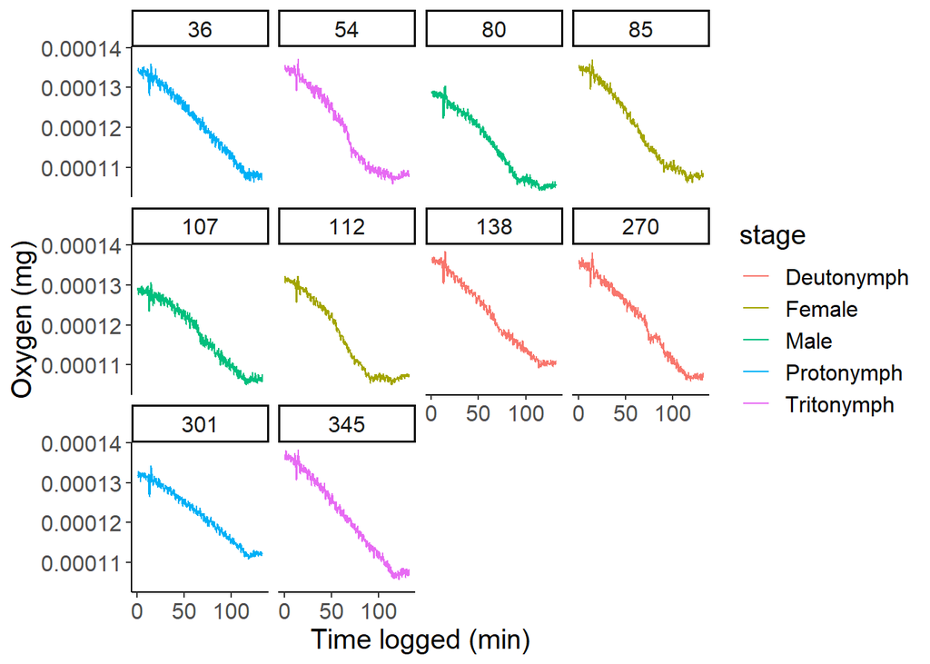

```r
ggplot(ox8, aes(x=logtime, y=oxymg,group=ind, color=stage))+ #MODIFY FOR EACH TRIAL
  geom_line()+
  theme_classic()+
  theme(text = element_text(size = 15))+
 # ylim(8,12) +
  facet_wrap(~ind)+
  xlab("Time logged (min)")+
  ylab("Oxygen (mg)")
```

### 3.2.8 Trial 9

```r
# creating vector for columns names
cnames<-c("date", "time", "logtime", "oxygen", "phase", "amplitude", "temperature")

# creating vector for path
path<-"Data/Oxygen/Trial 9/" #MODIFY FOR EEACH TRIAL

# Creating list of file names
list <- list.files(path = path, pattern=".*txt") # creates the list of all the txt files in the directory

# Renaming files to remove the "-"
newname <- sub('-','', list) ## new name
file.rename(file.path(path,list), file.path(path, newname)) ## renaming it.
```

```
##  [1] TRUE TRUE TRUE TRUE TRUE TRUE TRUE TRUE TRUE TRUE
```

```r
# Creating list of file names again
list <- list.files(path = path, pattern=".*txt") # creates the list of all the txt files in the directory

#Reading all files at once
for (i in list) {
  filename <- paste0( "frame",sub(pattern = "(.*)\\..*$", replacement = "\\1", basename(i)))
  wd <- paste0(path, i)
  assign(filename, read.delim2(wd,sep=";", skip=38, header=F, col.names=cnames)) #CHECK FOR EACH TRIALS IF THE SAME NUMBRE OF ROWS APPLIES

}


# Merging all into a single table
pattern<-grep("framepstrial9",names(.GlobalEnv),value=TRUE) #MODIFY FOR EACH TRIAL
list2<-do.call("list",mget(pattern))

t9a<-bind_rows(list2, .id="id") #MODIFY FOR EACH TRIAL


# Adding and modifying data to phase files
t9b<-t9a %>% #MODIFY FOR EACH TRIAL
  select(c("id", "date", "time", "logtime", "phase")) %>%
  mutate(trial=9,#MODIFY FOR EACH TRIAL
         date=mdy(date), #formatting date
         datetime=paste0(date," ", time), #copying date and time together
         datetime=as_datetime(datetime, format="%Y-%m-%d %I:%M:%S %p")-minutes(9), #adjusting pc time to real time
         datetime2=round_date(datetime, unit="minute"),
         channel=case_when(str_detect(id, "ch10")~10, # Assigning channels
                       str_detect(id, "ch1")~1,
                       str_detect(id, "ch2")~2,
                       str_detect(id, "ch3")~3,
                       str_detect(id, "ch4")~4,
                       str_detect(id, "ch5")~5,
                       str_detect(id, "ch6")~6,
                       str_detect(id, "ch7")~7,
                       str_detect(id, "ch8")~8,
                       str_detect(id, "ch9")~9,
                       TRUE~0),
         ind=case_when(str_detect(id, "ch10")~007, # Assigning individuals MODIFY FOR EACH TRIAL
                       str_detect(id, "ch1")~242,
                       str_detect(id, "ch2")~035,
                       str_detect(id, "ch3")~146,
                       str_detect(id, "ch4")~153,
                       str_detect(id, "ch5")~334,
                       str_detect(id, "ch6")~264,
                       str_detect(id, "ch7")~1000,
                       str_detect(id, "ch8")~004,
                       str_detect(id, "ch9")~228,
                       TRUE~0),
         stage=case_when(str_detect(id, "ch10")~"Male",#Assigning stage MODIFY FOR EACH TRIAL
                       str_detect(id, "ch1")~"Female",
                         str_detect(id, "ch2")~"Protonymph",
                       str_detect(id, "ch3")~"Male",
                       str_detect(id, "ch4")~"Tritonymph",
                       str_detect(id, "ch5")~"Deutonymph",
                       str_detect(id, "ch6")~"Deutonymph",
                       str_detect(id, "ch7")~"NA",
                       str_detect(id, "ch8")~"Female",
                       #str_detect(id, "ch9")~"Male",
                       TRUE~"Tritonymph"),
         weight=case_when(str_detect(id, "ch10")~0.983, # Assigning weights MODIFY FOR EACH TRIAL
                       str_detect(id, "ch1")~1.775,
                       str_detect(id, "ch2")~0.185,
                       str_detect(id, "ch3")~1.118,
                       str_detect(id, "ch4")~0.551,
                       str_detect(id, "ch5")~0.302,
                       str_detect(id, "ch6")~0.342,
                       str_detect(id, "ch7")~1000,
                       str_detect(id, "ch8")~1.425,
                       #str_detect(id, "ch9")~1.001,
                       TRUE~0.569),
         atm=round(33.864*28.66)) #MODIFY FOR EACH TRIAL: 33.864 * pressure in inHg

# Getting temperature for this trial
temp2<-all_corr %>%
  filter(trial==9) %>% #MODIFY FOR EACH TRIAL
  select(c("datetime2","datetime", "tempcorr", "ramp"))

#Merging phase and temperature data
t9<- full_join(t9b, temp2, by="datetime2", suffix=c("",".temp")) #MODIFY FOR EACH TRIAL


head(t9) #MODIFY FOR EACH TRIAL
```

|  | id | date | time | logtime | phase | trial | datetime | datetime2 | channel | ind | stage | weight | atm | datetime.temp | tempcorr | ramp |
| --- | --- | --- | --- | --- | --- | --- | --- | --- | --- | --- | --- | --- | --- | --- | --- | --- |
| 1 | framepstrial9ch10 | 2022-06-23 | 12:49:32 PM | 0.00 | 26.630 | 9 | 2022-06-23 12:40:32 | 2022-06-23 12:41:00 | 10 | 7 | Male | 0.983 | 971 | 2022-06-23 12:40:38 | 29.97319 | 0.2509365 |
| 2 | framepstrial9ch10 | 2022-06-23 | 12:49:32 PM | 0.00 | 26.630 | 9 | 2022-06-23 12:40:32 | 2022-06-23 12:41:00 | 10 | 7 | Male | 0.983 | 971 | 2022-06-23 12:41:08 | 29.94592 | 0.2509365 |
| 3 | framepstrial9ch10 | 2022-06-23 | 12:49:34 PM | 0.03 | 26.790 | 9 | 2022-06-23 12:40:34 | 2022-06-23 12:41:00 | 10 | 7 | Male | 0.983 | 971 | 2022-06-23 12:40:38 | 29.97319 | 0.2509365 |
| 4 | framepstrial9ch10 | 2022-06-23 | 12:49:34 PM | 0.03 | 26.790 | 9 | 2022-06-23 12:40:34 | 2022-06-23 12:41:00 | 10 | 7 | Male | 0.983 | 971 | 2022-06-23 12:41:08 | 29.94592 | 0.2509365 |
| 5 | framepstrial9ch10 | 2022-06-23 | 12:49:47 PM | 0.24 | 26.710 | 9 | 2022-06-23 12:40:47 | 2022-06-23 12:41:00 | 10 | 7 | Male | 0.983 | 971 | 2022-06-23 12:40:38 | 29.97319 | 0.2509365 |
| 6 | framepstrial9ch10 | 2022-06-23 | 12:49:47 PM | 0.24 | 26.710 | 9 | 2022-06-23 12:40:47 | 2022-06-23 12:41:00 | 10 | 7 | Male | 0.983 | 971 | 2022-06-23 12:41:08 | 29.94592 | 0.2509365 |

```r
#Estimating Oxygen
f<-pi/180
f
```

```
## [1] 0.01745329
```

```r
ox9<-t9 %>% #MODIFY FOR EACH TRIAL
  na.omit() %>%
  filter(ind < 900) %>%
  mutate(phase=as.numeric(phase),
         ind=as.factor(ind),
         logtime=as.numeric(logtime),
         phaseangle=62.14-0.08915*tempcorr,
         sternvolmer=0.04899+4.965*10^(-4)*tempcorr,
         bunsen=(48.998-1.335*tempcorr+2.755*10^(-2)*tempcorr^2-3.22*10^(-4)*tempcorr^3+1.598*10^(-6)*tempcorr^4)*10^(-3),
         tempK=tempcorr+273,
         watervapor=exp(52.57-(6690.9/tempK)-4.681*log(tempK)),
         oxysat=(tan((pi/180)*phaseangle)-tan((pi/180)*phase))/tan((pi/180)*phase)*sternvolmer,
         oxymgl=(atm-watervapor)/1013*oxysat*0.2095*bunsen*1000*(32/22.414)*10,
         oxymg=oxymgl*volume)

head(ox9) #MODIFY FOR EACH TRIAL
```

|  | id | date | time | logtime | phase | trial | datetime | datetime2 | channel | ind | stage | weight | atm | datetime.temp | tempcorr | ramp | phaseangle | sternvolmer | bunsen | tempK | watervapor | oxysat | oxymgl | oxymg |
| --- | --- | --- | --- | --- | --- | --- | --- | --- | --- | --- | --- | --- | --- | --- | --- | --- | --- | --- | --- | --- | --- | --- | --- | --- |
| 1 | framepstrial9ch10 | 2022-06-23 | 12:49:32 PM | 0.00 | 26.63 | 9 | 2022-06-23 12:40:32 | 2022-06-23 12:41:00 | 10 | 7 | Male | 0.983 | 971 | 2022-06-23 12:40:38 | 29.97319 | 0.2509365 | 59.46789 | 0.06387169 | 0.02635354 | 302.9732 | 42.11056 | 0.1521035 | 10.99379 | 0.0001381520 |
| 2 | framepstrial9ch10 | 2022-06-23 | 12:49:32 PM | 0.00 | 26.63 | 9 | 2022-06-23 12:40:32 | 2022-06-23 12:41:00 | 10 | 7 | Male | 0.983 | 971 | 2022-06-23 12:41:08 | 29.94592 | 0.2509365 | 59.47032 | 0.06385815 | 0.02636389 | 302.9459 | 42.04466 | 0.1520922 | 10.99807 | 0.0001382058 |
| 3 | framepstrial9ch10 | 2022-06-23 | 12:49:34 PM | 0.03 | 26.79 | 9 | 2022-06-23 12:40:34 | 2022-06-23 12:41:00 | 10 | 7 | Male | 0.983 | 971 | 2022-06-23 12:40:38 | 29.97319 | 0.2509365 | 59.46789 | 0.06387169 | 0.02635354 | 302.9732 | 42.11056 | 0.1506066 | 10.88559 | 0.0001367924 |
| 4 | framepstrial9ch10 | 2022-06-23 | 12:49:34 PM | 0.03 | 26.79 | 9 | 2022-06-23 12:40:34 | 2022-06-23 12:41:00 | 10 | 7 | Male | 0.983 | 971 | 2022-06-23 12:41:08 | 29.94592 | 0.2509365 | 59.47032 | 0.06385815 | 0.02636389 | 302.9459 | 42.04466 | 0.1505954 | 10.88983 | 0.0001368457 |
| 5 | framepstrial9ch10 | 2022-06-23 | 12:49:47 PM | 0.24 | 26.71 | 9 | 2022-06-23 12:40:47 | 2022-06-23 12:41:00 | 10 | 7 | Male | 0.983 | 971 | 2022-06-23 12:40:38 | 29.97319 | 0.2509365 | 59.46789 | 0.06387169 | 0.02635354 | 302.9732 | 42.11056 | 0.1513529 | 10.93954 | 0.0001374703 |
| 6 | framepstrial9ch10 | 2022-06-23 | 12:49:47 PM | 0.24 | 26.71 | 9 | 2022-06-23 12:40:47 | 2022-06-23 12:41:00 | 10 | 7 | Male | 0.983 | 971 | 2022-06-23 12:41:08 | 29.94592 | 0.2509365 | 59.47032 | 0.06385815 | 0.02636389 | 302.9459 | 42.04466 | 0.1513417 | 10.94380 | 0.0001375238 |

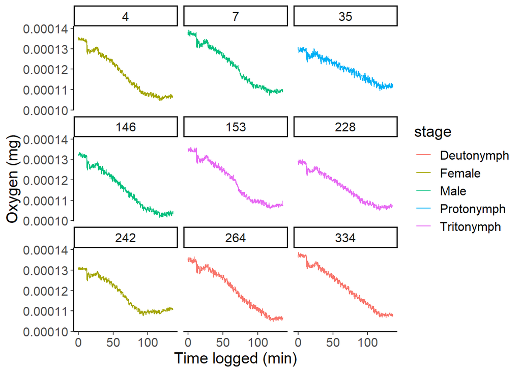

```r
ggplot(ox9, aes(x=logtime, y=oxymg,group=ind, color=stage))+ #MODIFY FOR EACH TRIAL
  geom_line()+
  theme_classic()+
  theme(text = element_text(size = 15))+
  #ylim(8,12) +
  facet_wrap(~ind)+
  xlab("Time logged (min)")+
  ylab("Oxygen (mg)")
```

### 3.2.9 Trial 10

```r
# creating vector for columns names
cnames<-c("date", "time", "logtime", "oxygen", "phase", "amplitude", "temperature")

# creating vector for path
path<-"Data/Oxygen/Trial 10/" #MODIFY FOR EEACH TRIAL

# Creating list of file names
list <- list.files(path = path, pattern=".*txt") # creates the list of all the txt files in the directory

# Renaming files to remove the "-"
newname <- sub('-','', list) ## new name
file.rename(file.path(path,list), file.path(path, newname)) ## renaming it.
```

```
##  [1] TRUE TRUE TRUE TRUE TRUE TRUE TRUE TRUE TRUE TRUE
```

```r
# Creating list of file names again
list <- list.files(path = path, pattern=".*txt") # creates the list of all the txt files in the directory

#Reading all files at once
for (i in list) {
  filename <- paste0( "frame",sub(pattern = "(.*)\\..*$", replacement = "\\1", basename(i)))
  wd <- paste0(path, i)
  assign(filename, read.delim2(wd,sep=";", skip=38, header=F, col.names=cnames)) #CHECK FOR EACH TRIALS IF THE SAME NUMBRE OF ROWS APPLIES

}


# Merging all into a single table
pattern<-grep("framepstrial10",names(.GlobalEnv),value=TRUE) #MODIFY FOR EACH TRIAL
list2<-do.call("list",mget(pattern))

t10a<-bind_rows(list2, .id="id") #MODIFY FOR EACH TRIAL


# Adding and modifying data to phase files
t10b<-t10a %>% #MODIFY FOR EACH TRIAL
  select(c("id", "date", "time", "logtime", "phase")) %>%
  mutate(trial=10,#MODIFY FOR EACH TRIAL
         date=mdy(date), #formatting date
         datetime=paste0(date," ", time), #copying date and time together
         datetime=as_datetime(datetime, format="%Y-%m-%d %I:%M:%S %p")-minutes(9), #adjusting pc time to real time
         datetime2=round_date(datetime, unit="minute"),
         channel=case_when(str_detect(id, "ch10")~10, # Assigning channels
                       str_detect(id, "ch1")~1,
                       str_detect(id, "ch2")~2,
                       str_detect(id, "ch3")~3,
                       str_detect(id, "ch4")~4,
                       str_detect(id, "ch5")~5,
                       str_detect(id, "ch6")~6,
                       str_detect(id, "ch7")~7,
                       str_detect(id, "ch8")~8,
                       str_detect(id, "ch9")~9,
                       TRUE~0),
         ind=case_when(str_detect(id, "ch10")~179, # Assigning individuals MODIFY FOR EACH TRIAL
                       str_detect(id, "ch1")~048,
                       str_detect(id, "ch2")~158,
                       str_detect(id, "ch3")~079,
                       str_detect(id, "ch4")~145,
                       str_detect(id, "ch5")~057,
                       str_detect(id, "ch6")~251,
                       str_detect(id, "ch7")~248,
                       str_detect(id, "ch8")~314,
                       str_detect(id, "ch9")~212,
                       TRUE~0),
         stage=case_when(str_detect(id, "ch10")~"Tritonymph",#Assigning stage MODIFY FOR EACH TRIAL
                       str_detect(id, "ch1")~"Deutonymph",
                         str_detect(id, "ch2")~"Female",
                       str_detect(id, "ch3")~"Female",
                       str_detect(id, "ch4")~"Male",
                       str_detect(id, "ch5")~"Tritonymph",
                       str_detect(id, "ch6")~"Male",
                       str_detect(id, "ch7")~"Male",
                       str_detect(id, "ch8")~"Deutonymph",
                       #str_detect(id, "ch9")~"",
                       TRUE~"Female"),
         weight=case_when(str_detect(id, "ch10")~0.653, # Assigning weights MODIFY FOR EACH TRIAL
                       str_detect(id, "ch1")~0.451,
                       str_detect(id, "ch2")~1.178,
                       str_detect(id, "ch3")~1.781,
                       str_detect(id, "ch4")~0.929,
                       str_detect(id, "ch5")~0.866,
                       str_detect(id, "ch6")~0.941,
                       str_detect(id, "ch7")~0.864,
                       str_detect(id, "ch8")~0.188,
                       #str_detect(id, "ch9")~1.001,
                       TRUE~1.582),
         atm=round(33.864*28.64)) #MODIFY FOR EACH TRIAL: 33.864 * pressure in inHg

# Getting temperature for this trial
temp2<-all_corr %>%
  filter(trial==10) %>% #MODIFY FOR EACH TRIAL
  select(c("datetime2","datetime", "tempcorr", "ramp"))

#Merging phase and temperature data
t10<- full_join(t10b, temp2, by="datetime2", suffix=c("",".temp")) #MODIFY FOR EACH TRIAL


head(t10) #MODIFY FOR EACH TRIAL
```

|  | id | date | time | logtime | phase | trial | datetime | datetime2 | channel | ind | stage | weight | atm | datetime.temp | tempcorr | ramp |
| --- | --- | --- | --- | --- | --- | --- | --- | --- | --- | --- | --- | --- | --- | --- | --- | --- |
| 1 | framepstrial10ch6 | 2022-06-23 | 3:47:27 PM | 0.00 | 27.080 | 10 | 2022-06-23 15:38:27 | 2022-06-23 15:38:00 | 6 | 251 | Male | 0.941 | 970 | 2022-06-23 15:38:08 | 29.94592 | 0.2516338 |
| 2 | framepstrial10ch6 | 2022-06-23 | 3:47:36 PM | 0.15 | 27.340 | 10 | 2022-06-23 15:38:36 | 2022-06-23 15:39:00 | 6 | 251 | Male | 0.941 | 970 | 2022-06-23 15:38:38 | 29.89085 | 0.2516338 |
| 3 | framepstrial10ch6 | 2022-06-23 | 3:47:36 PM | 0.15 | 27.340 | 10 | 2022-06-23 15:38:36 | 2022-06-23 15:39:00 | 6 | 251 | Male | 0.941 | 970 | 2022-06-23 15:39:08 | 30.01409 | 0.2516338 |
| 4 | framepstrial10ch6 | 2022-06-23 | 3:47:51 PM | 0.40 | 27.320 | 10 | 2022-06-23 15:38:51 | 2022-06-23 15:39:00 | 6 | 251 | Male | 0.941 | 970 | 2022-06-23 15:38:38 | 29.89085 | 0.2516338 |
| 5 | framepstrial10ch6 | 2022-06-23 | 3:47:51 PM | 0.40 | 27.320 | 10 | 2022-06-23 15:38:51 | 2022-06-23 15:39:00 | 6 | 251 | Male | 0.941 | 970 | 2022-06-23 15:39:08 | 30.01409 | 0.2516338 |
| 6 | framepstrial10ch6 | 2022-06-23 | 3:48:06 PM | 0.65 | 27.340 | 10 | 2022-06-23 15:39:06 | 2022-06-23 15:39:00 | 6 | 251 | Male | 0.941 | 970 | 2022-06-23 15:38:38 | 29.89085 | 0.2516338 |

```r
#Estimating Oxygen
f<-pi/180
f
```

```
## [1] 0.01745329
```

```r
ox10<-t10 %>% #MODIFY FOR EACH TRIAL
  na.omit() %>%
  filter(ind < 900) %>%
  mutate(phase=as.numeric(phase),
         ind=as.factor(ind),
         logtime=as.numeric(logtime),
         phaseangle=62.14-0.08915*tempcorr,
         sternvolmer=0.04899+4.965*10^(-4)*tempcorr,
         bunsen=(48.998-1.335*tempcorr+2.755*10^(-2)*tempcorr^2-3.22*10^(-4)*tempcorr^3+1.598*10^(-6)*tempcorr^4)*10^(-3),
         tempK=tempcorr+273,
         watervapor=exp(52.57-(6690.9/tempK)-4.681*log(tempK)),
         oxysat=(tan((pi/180)*phaseangle)-tan((pi/180)*phase))/tan((pi/180)*phase)*sternvolmer,
         oxymgl=(atm-watervapor)/1013*oxysat*0.2095*bunsen*1000*(32/22.414)*10,
         oxymg=oxymgl*volume)

head(ox10) #MODIFY FOR EACH TRIAL
```

|  | id | date | time | logtime | phase | trial | datetime | datetime2 | channel | ind | stage | weight | atm | datetime.temp | tempcorr | ramp | phaseangle | sternvolmer | bunsen | tempK | watervapor | oxysat | oxymgl | oxymg |
| --- | --- | --- | --- | --- | --- | --- | --- | --- | --- | --- | --- | --- | --- | --- | --- | --- | --- | --- | --- | --- | --- | --- | --- | --- |
| 1 | framepstrial10ch6 | 2022-06-23 | 3:47:27 PM | 0.00 | 27.08 | 10 | 2022-06-23 15:38:27 | 2022-06-23 15:38:00 | 6 | 251 | Male | 0.941 | 970 | 2022-06-23 15:38:08 | 29.94592 | 0.2516338 | 59.47032 | 0.06385815 | 0.02636389 | 302.9459 | 42.04466 | 0.1479244 | 10.68517 | 0.0001342738 |
| 2 | framepstrial10ch6 | 2022-06-23 | 3:47:36 PM | 0.15 | 27.34 | 10 | 2022-06-23 15:38:36 | 2022-06-23 15:39:00 | 6 | 251 | Male | 0.941 | 970 | 2022-06-23 15:38:38 | 29.89085 | 0.2516338 | 59.47523 | 0.06383081 | 0.02638481 | 302.8908 | 41.91180 | 0.1455529 | 10.52372 | 0.0001322450 |
| 3 | framepstrial10ch6 | 2022-06-23 | 3:47:36 PM | 0.15 | 27.34 | 10 | 2022-06-23 15:38:36 | 2022-06-23 15:39:00 | 6 | 251 | Male | 0.941 | 970 | 2022-06-23 15:39:08 | 30.01409 | 0.2516338 | 59.46424 | 0.06389199 | 0.02633805 | 303.0141 | 42.20959 | 0.1456006 | 10.50514 | 0.0001320114 |
| 4 | framepstrial10ch6 | 2022-06-23 | 3:47:51 PM | 0.40 | 27.32 | 10 | 2022-06-23 15:38:51 | 2022-06-23 15:39:00 | 6 | 251 | Male | 0.941 | 970 | 2022-06-23 15:38:38 | 29.89085 | 0.2516338 | 59.47523 | 0.06383081 | 0.02638481 | 302.8908 | 41.91180 | 0.1457321 | 10.53668 | 0.0001324078 |
| 5 | framepstrial10ch6 | 2022-06-23 | 3:47:51 PM | 0.40 | 27.32 | 10 | 2022-06-23 15:38:51 | 2022-06-23 15:39:00 | 6 | 251 | Male | 0.941 | 970 | 2022-06-23 15:39:08 | 30.01409 | 0.2516338 | 59.46424 | 0.06389199 | 0.02633805 | 303.0141 | 42.20959 | 0.1457799 | 10.51808 | 0.0001321741 |
| 6 | framepstrial10ch6 | 2022-06-23 | 3:48:06 PM | 0.65 | 27.34 | 10 | 2022-06-23 15:39:06 | 2022-06-23 15:39:00 | 6 | 251 | Male | 0.941 | 970 | 2022-06-23 15:38:38 | 29.89085 | 0.2516338 | 59.47523 | 0.06383081 | 0.02638481 | 302.8908 | 41.91180 | 0.1455529 | 10.52372 | 0.0001322450 |

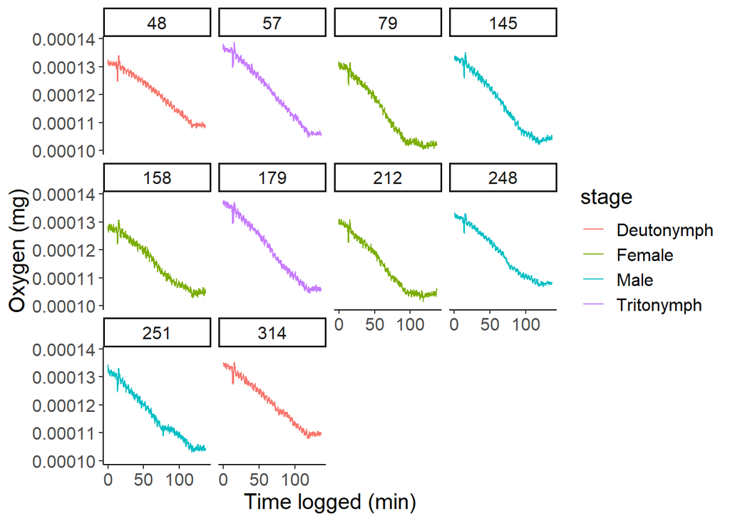

```r
ggplot(ox10, aes(x=logtime, y=oxymg,group=ind, color=stage))+ #MODIFY FOR EACH TRIAL
  geom_line()+
  theme_classic()+
  theme(text = element_text(size = 15))+
  #ylim(8,12) +
  facet_wrap(~ind)+
  xlab("Time logged (min)")+
  ylab("Oxygen (mg)")
```

### 3.2.10 Trial 11

```r
# creating vector for columns names
cnames<-c("date", "time", "logtime", "oxygen", "phase", "amplitude", "temperature")

# creating vector for path
path<-"Data/Oxygen/Trial 11/" #MODIFY FOR EEACH TRIAL

# Creating list of file names
list <- list.files(path = path, pattern=".*txt") # creates the list of all the txt files in the directory

# Renaming files to remove the "-"
newname <- sub('-','', list) ## new name
file.rename(file.path(path,list), file.path(path, newname)) ## renaming it.
```

```
##  [1] TRUE TRUE TRUE TRUE TRUE TRUE TRUE TRUE TRUE TRUE
```

```r
# Creating list of file names again
list <- list.files(path = path, pattern=".*txt") # creates the list of all the txt files in the directory

#Reading all files at once
for (i in list) {
  filename <- paste0( "frame",sub(pattern = "(.*)\\..*$", replacement = "\\1", basename(i)))
  wd <- paste0(path, i)
  assign(filename, read.delim2(wd,sep=";", skip=38, header=F, col.names=cnames)) #CHECK FOR EACH TRIALS IF THE SAME NUMBRE OF ROWS APPLIES

}


# Merging all into a single table
pattern<-grep("framepstrial11",names(.GlobalEnv),value=TRUE) #MODIFY FOR EACH TRIAL
list2<-do.call("list",mget(pattern))

t11a<-bind_rows(list2, .id="id") #MODIFY FOR EACH TRIAL


# Adding and modifying data to phase files
t11b<-t11a %>% #MODIFY FOR EACH TRIAL
  select(c("id", "date", "time", "logtime", "phase")) %>%
  mutate(trial=11,#MODIFY FOR EACH TRIAL
         date=mdy(date), #formatting date
         datetime=paste0(date," ", time), #copying date and time together
         datetime=as_datetime(datetime, format="%Y-%m-%d %I:%M:%S %p")-minutes(9), #adjusting pc time to real time
         datetime2=round_date(datetime, unit="minute"),
         channel=case_when(str_detect(id, "ch10")~10, # Assigning channels
                       str_detect(id, "ch1")~1,
                       str_detect(id, "ch2")~2,
                       str_detect(id, "ch3")~3,
                       str_detect(id, "ch4")~4,
                       str_detect(id, "ch5")~5,
                       str_detect(id, "ch6")~6,
                       str_detect(id, "ch7")~7,
                       str_detect(id, "ch8")~8,
                       str_detect(id, "ch9")~9,
                       TRUE~0),
         ind=case_when(str_detect(id, "ch10")~141, # Assigning individuals MODIFY FOR EACH TRIAL
                       str_detect(id, "ch1")~272,
                       str_detect(id, "ch2")~305,
                       str_detect(id, "ch3")~326,
                       str_detect(id, "ch4")~224,
                       str_detect(id, "ch5")~173,
                       str_detect(id, "ch6")~214,
                       str_detect(id, "ch7")~082,
                       str_detect(id, "ch8")~113,
                       str_detect(id, "ch9")~329,
                       TRUE~0),
         stage=case_when(str_detect(id, "ch10")~"Female",#Assigning stage MODIFY FOR EACH TRIAL
                       str_detect(id, "ch1")~"Tritonymph",
                         str_detect(id, "ch2")~"Deutonymph",
                       str_detect(id, "ch3")~"Deutonymph",
                       str_detect(id, "ch4")~"Female",
                       str_detect(id, "ch5")~"Tritonymph",
                       str_detect(id, "ch6")~"Deutonymph",
                       str_detect(id, "ch7")~"Male",
                       str_detect(id, "ch8")~"Male",
                       #str_detect(id, "ch9")~"",
                       TRUE~"Tritonymph"),
         weight=case_when(str_detect(id, "ch10")~1.853, # Assigning weights MODIFY FOR EACH TRIAL
                       str_detect(id, "ch1")~0.675,
                       str_detect(id, "ch2")~0.312,
                       str_detect(id, "ch3")~0.283,
                       str_detect(id, "ch4")~1.785,
                       str_detect(id, "ch5")~0.566,
                       str_detect(id, "ch6")~0.184,
                       str_detect(id, "ch7")~1.095,
                       str_detect(id, "ch8")~1.046,
                       #str_detect(id, "ch9")~1.001,
                       TRUE~0.591),
         atm=round(33.864*28.55)) #MODIFY FOR EACH TRIAL: 33.864 * pressure in inHg

# Getting temperature for this trial
temp2<-all_corr %>%
  filter(trial==11) %>% #MODIFY FOR EACH TRIAL
  select(c("datetime2","datetime", "tempcorr", "ramp"))

#Merging phase and temperature data
t11<- full_join(t11b, temp2, by="datetime2", suffix=c("",".temp")) #MODIFY FOR EACH TRIAL


head(t11) #MODIFY FOR EACH TRIAL
```

|  | id | date | time | logtime | phase | trial | datetime | datetime2 | channel | ind | stage | weight | atm | datetime.temp | tempcorr | ramp |
| --- | --- | --- | --- | --- | --- | --- | --- | --- | --- | --- | --- | --- | --- | --- | --- | --- |
| 1 | framepstrial11ch1 | 2022-06-23 | 6:43:14 PM | 0.00 | 27.440 | 11 | 2022-06-23 18:34:14 | 2022-06-23 18:34:00 | 1 | 272 | Tritonymph | 0.675 | 967 | 2022-06-23 18:33:38 | 30.00045 | 0.2530779 |
| 2 | framepstrial11ch1 | 2022-06-23 | 6:43:14 PM | 0.00 | 27.440 | 11 | 2022-06-23 18:34:14 | 2022-06-23 18:34:00 | 1 | 272 | Tritonymph | 0.675 | 967 | 2022-06-23 18:34:08 | 29.97264 | 0.2530779 |
| 3 | framepstrial11ch1 | 2022-06-23 | 6:43:26 PM | 0.19 | 27.400 | 11 | 2022-06-23 18:34:26 | 2022-06-23 18:34:00 | 1 | 272 | Tritonymph | 0.675 | 967 | 2022-06-23 18:33:38 | 30.00045 | 0.2530779 |
| 4 | framepstrial11ch1 | 2022-06-23 | 6:43:26 PM | 0.19 | 27.400 | 11 | 2022-06-23 18:34:26 | 2022-06-23 18:34:00 | 1 | 272 | Tritonymph | 0.675 | 967 | 2022-06-23 18:34:08 | 29.97264 | 0.2530779 |
| 5 | framepstrial11ch1 | 2022-06-23 | 6:43:41 PM | 0.44 | 27.420 | 11 | 2022-06-23 18:34:41 | 2022-06-23 18:35:00 | 1 | 272 | Tritonymph | 0.675 | 967 | 2022-06-23 18:34:38 | 29.97264 | 0.2530779 |
| 6 | framepstrial11ch1 | 2022-06-23 | 6:43:41 PM | 0.44 | 27.420 | 11 | 2022-06-23 18:34:41 | 2022-06-23 18:35:00 | 1 | 272 | Tritonymph | 0.675 | 967 | 2022-06-23 18:35:08 | 30.05498 | 0.2530779 |

```r
#Estimating Oxygen
f<-pi/180
f
```

```
## [1] 0.01745329
```

```r
ox11<-t11 %>% #MODIFY FOR EACH TRIAL
  na.omit() %>%
  filter(ind < 900) %>%
  mutate(phase=as.numeric(phase),
         ind=as.factor(ind),
         logtime=as.numeric(logtime),
         phaseangle=62.14-0.08915*tempcorr,
         sternvolmer=0.04899+4.965*10^(-4)*tempcorr,
         bunsen=(48.998-1.335*tempcorr+2.755*10^(-2)*tempcorr^2-3.22*10^(-4)*tempcorr^3+1.598*10^(-6)*tempcorr^4)*10^(-3),
         tempK=tempcorr+273,
         watervapor=exp(52.57-(6690.9/tempK)-4.681*log(tempK)),
         oxysat=(tan((pi/180)*phaseangle)-tan((pi/180)*phase))/tan((pi/180)*phase)*sternvolmer,
         oxymgl=(atm-watervapor)/1013*oxysat*0.2095*bunsen*1000*(32/22.414)*10,
         oxymg=oxymgl*volume)

head(ox11) #MODIFY FOR EACH TRIAL
```

|  | id | date | time | logtime | phase | trial | datetime | datetime2 | channel | ind | stage | weight | atm | datetime.temp | tempcorr | ramp | phaseangle | sternvolmer | bunsen | tempK | watervapor | oxysat | oxymgl | oxymg |
| --- | --- | --- | --- | --- | --- | --- | --- | --- | --- | --- | --- | --- | --- | --- | --- | --- | --- | --- | --- | --- | --- | --- | --- | --- |
| 1 | framepstrial11ch1 | 2022-06-23 | 6:43:14 PM | 0.00 | 27.44 | 11 | 2022-06-23 18:34:14 | 2022-06-23 18:34:00 | 1 | 272 | Tritonymph | 0.675 | 967 | 2022-06-23 18:33:38 | 30.00045 | 0.2530779 | 59.46546 | 0.06388523 | 0.02634321 | 303.0005 | 42.17656 | 0.1447021 | 10.40897 | 0.0001308029 |
| 2 | framepstrial11ch1 | 2022-06-23 | 6:43:14 PM | 0.00 | 27.44 | 11 | 2022-06-23 18:34:14 | 2022-06-23 18:34:00 | 1 | 272 | Tritonymph | 0.675 | 967 | 2022-06-23 18:34:08 | 29.97264 | 0.2530779 | 59.46794 | 0.06387142 | 0.02635375 | 302.9726 | 42.10924 | 0.1446915 | 10.41312 | 0.0001308552 |
| 3 | framepstrial11ch1 | 2022-06-23 | 6:43:26 PM | 0.19 | 27.40 | 11 | 2022-06-23 18:34:26 | 2022-06-23 18:34:00 | 1 | 272 | Tritonymph | 0.675 | 967 | 2022-06-23 18:33:38 | 30.00045 | 0.2530779 | 59.46546 | 0.06388523 | 0.02634321 | 303.0005 | 42.17656 | 0.1450587 | 10.43461 | 0.0001311252 |
| 4 | framepstrial11ch1 | 2022-06-23 | 6:43:26 PM | 0.19 | 27.40 | 11 | 2022-06-23 18:34:26 | 2022-06-23 18:34:00 | 1 | 272 | Tritonymph | 0.675 | 967 | 2022-06-23 18:34:08 | 29.97264 | 0.2530779 | 59.46794 | 0.06387142 | 0.02635375 | 302.9726 | 42.10924 | 0.1450480 | 10.43878 | 0.0001311776 |
| 5 | framepstrial11ch1 | 2022-06-23 | 6:43:41 PM | 0.44 | 27.42 | 11 | 2022-06-23 18:34:41 | 2022-06-23 18:35:00 | 1 | 272 | Tritonymph | 0.675 | 967 | 2022-06-23 18:34:38 | 29.97264 | 0.2530779 | 59.46794 | 0.06387142 | 0.02635375 | 302.9726 | 42.10924 | 0.1448696 | 10.42594 | 0.0001310163 |
| 6 | framepstrial11ch1 | 2022-06-23 | 6:43:41 PM | 0.44 | 27.42 | 11 | 2022-06-23 18:34:41 | 2022-06-23 18:35:00 | 1 | 272 | Tritonymph | 0.675 | 967 | 2022-06-23 18:35:08 | 30.05498 | 0.2530779 | 59.46060 | 0.06391230 | 0.02632257 | 303.0550 | 42.30882 | 0.1449012 | 10.41363 | 0.0001308616 |

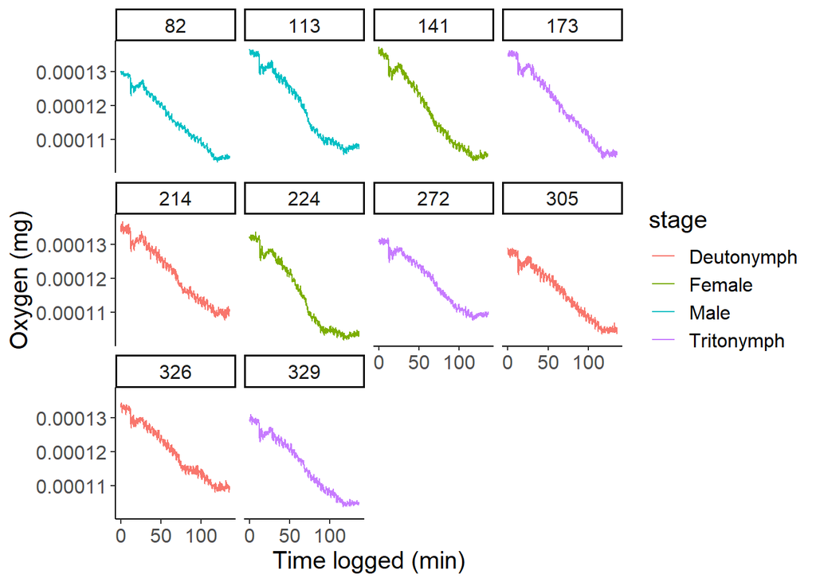

```r
ggplot(ox11, aes(x=logtime, y=oxymg,group=ind, color=stage))+ #MODIFY FOR EACH TRIAL
  geom_line()+
  theme_classic()+
  theme(text = element_text(size = 15))+
  #ylim(8,12) +
  facet_wrap(~ind)+
  xlab("Time logged (min)")+
  ylab("Oxygen (mg)")
```

### 3.2.11 Trial 12

```r
# creating vector for columns names
cnames<-c("date", "time", "logtime", "oxygen", "phase", "amplitude", "temperature")

# creating vector for path
path<-"Data/Oxygen/Trial 12/" #MODIFY FOR EEACH TRIAL

# Creating list of file names
list <- list.files(path = path, pattern=".*txt") # creates the list of all the txt files in the directory

# Renaming files to remove the "-"
newname <- sub('-','', list) ## new name
file.rename(file.path(path,list), file.path(path, newname)) ## renaming it.
```

```
##  [1] TRUE TRUE TRUE TRUE TRUE TRUE TRUE TRUE TRUE TRUE
```

```r
# Creating list of file names again
list <- list.files(path = path, pattern=".*txt") # creates the list of all the txt files in the directory

#Reading all files at once
for (i in list) {
  filename <- paste0( "frame",sub(pattern = "(.*)\\..*$", replacement = "\\1", basename(i)))
  wd <- paste0(path, i)
  assign(filename, read.delim2(wd,sep=";", skip=38, header=F, col.names=cnames)) #CHECK FOR EACH TRIALS IF THE SAME NUMBRE OF ROWS APPLIES

}


# Merging all into a single table
pattern<-grep("framepstrial12",names(.GlobalEnv),value=TRUE) #MODIFY FOR EACH TRIAL
list2<-do.call("list",mget(pattern))

t12a<-bind_rows(list2, .id="id") #MODIFY FOR EACH TRIAL


# Adding and modifying data to phase files
t12b<-t12a %>% #MODIFY FOR EACH TRIAL
  select(c("id", "date", "time", "logtime", "phase")) %>%
  mutate(trial=12,#MODIFY FOR EACH TRIAL
         date=mdy(date), #formatting date
         datetime=paste0(date," ", time), #copying date and time together
         datetime=as_datetime(datetime, format="%Y-%m-%d %I:%M:%S %p")-minutes(9), #adjusting pc time to real time
         datetime2=round_date(datetime, unit="minute"),
         channel=case_when(str_detect(id, "ch10")~10, # Assigning channels
                       str_detect(id, "ch1")~1,
                       str_detect(id, "ch2")~2,
                       str_detect(id, "ch3")~3,
                       str_detect(id, "ch4")~4,
                       str_detect(id, "ch5")~5,
                       str_detect(id, "ch6")~6,
                       str_detect(id, "ch7")~7,
                       str_detect(id, "ch8")~8,
                       str_detect(id, "ch9")~9,
                       TRUE~0),
         ind=case_when(str_detect(id, "ch10")~339, # Assigning individuals MODIFY FOR EACH TRIAL
                       str_detect(id, "ch1")~256,
                       str_detect(id, "ch2")~341,
                       str_detect(id, "ch3")~18,
                       str_detect(id, "ch4")~83,
                       str_detect(id, "ch5")~50,
                       str_detect(id, "ch6")~201,
                       str_detect(id, "ch7")~211,
                       str_detect(id, "ch8")~317,
                       str_detect(id, "ch9")~335,
                       TRUE~0),
         stage=case_when(str_detect(id, "ch10")~"Deutonymph",#Assigning stage MODIFY FOR EACH TRIAL
                       str_detect(id, "ch1")~"Female",
                         str_detect(id, "ch2")~"Tritonymph",
                       str_detect(id, "ch3")~"Male",
                       str_detect(id, "ch4")~"Male",
                       str_detect(id, "ch5")~"Male",
                       str_detect(id, "ch6")~"Female",
                       str_detect(id, "ch7")~"Female",
                       str_detect(id, "ch8")~"Tritonymph",
                       #str_detect(id, "ch9")~"",
                       TRUE~"Deutonymph"),
         weight=case_when(str_detect(id, "ch10")~0.314, # Assigning weights MODIFY FOR EACH TRIAL
                       str_detect(id, "ch1")~1.450,
                       str_detect(id, "ch2")~0.790,
                       str_detect(id, "ch3")~1.23,
                       str_detect(id, "ch4")~1.015,
                       str_detect(id, "ch5")~1.229,
                       str_detect(id, "ch6")~1.49,
                       str_detect(id, "ch7")~1.500,
                       str_detect(id, "ch8")~0.905,
                       #str_detect(id, "ch9")~1.001,
                       TRUE~0.268),
         atm=round(33.864*28.58)) #MODIFY FOR EACH TRIAL: 33.864 * pressure in inHg

# Getting temperature for this trial
temp2<-all_corr %>%
  filter(trial==12) %>% #MODIFY FOR EACH TRIAL
  select(c("datetime2","datetime", "tempcorr", "ramp"))

#Merging phase and temperature data
t12<- full_join(t12b, temp2, by="datetime2", suffix=c("",".temp")) #MODIFY FOR EACH TRIAL


head(t12) #MODIFY FOR EACH TRIAL
```

|  | id | date | time | logtime | phase | trial | datetime | datetime2 | channel | ind | stage | weight | atm | datetime.temp | tempcorr | ramp |
| --- | --- | --- | --- | --- | --- | --- | --- | --- | --- | --- | --- | --- | --- | --- | --- | --- |
| 1 | framepstrial12ch6 | 2022-06-23 | 9:53:06 PM | 0.00 | 27.310 | 12 | 2022-06-23 21:44:06 | 2022-06-23 21:44:00 | 6 | 201 | Female | 1.49 | 968 | 2022-06-23 21:43:38 | 29.95956 | 0.2488963 |
| 2 | framepstrial12ch6 | 2022-06-23 | 9:53:06 PM | 0.00 | 27.310 | 12 | 2022-06-23 21:44:06 | 2022-06-23 21:44:00 | 6 | 201 | Female | 1.49 | 968 | 2022-06-23 21:44:08 | 29.89085 | 0.2488963 |
| 3 | framepstrial12ch6 | 2022-06-23 | 9:53:11 PM | 0.09 | 27.350 | 12 | 2022-06-23 21:44:11 | 2022-06-23 21:44:00 | 6 | 201 | Female | 1.49 | 968 | 2022-06-23 21:43:38 | 29.95956 | 0.2488963 |
| 4 | framepstrial12ch6 | 2022-06-23 | 9:53:11 PM | 0.09 | 27.350 | 12 | 2022-06-23 21:44:11 | 2022-06-23 21:44:00 | 6 | 201 | Female | 1.49 | 968 | 2022-06-23 21:44:08 | 29.89085 | 0.2488963 |
| 5 | framepstrial12ch6 | 2022-06-23 | 9:53:26 PM | 0.34 | 27.230 | 12 | 2022-06-23 21:44:26 | 2022-06-23 21:44:00 | 6 | 201 | Female | 1.49 | 968 | 2022-06-23 21:43:38 | 29.95956 | 0.2488963 |
| 6 | framepstrial12ch6 | 2022-06-23 | 9:53:26 PM | 0.34 | 27.230 | 12 | 2022-06-23 21:44:26 | 2022-06-23 21:44:00 | 6 | 201 | Female | 1.49 | 968 | 2022-06-23 21:44:08 | 29.89085 | 0.2488963 |

```r
#Estimating Oxygen
f<-pi/180
f
```

```
## [1] 0.01745329
```

```r
ox12<-t12 %>% #MODIFY FOR EACH TRIAL
  na.omit() %>%
  filter(ind < 900) %>%
  mutate(phase=as.numeric(phase),
         ind=as.factor(ind),
         logtime=as.numeric(logtime),
         phaseangle=62.14-0.08915*tempcorr,
         sternvolmer=0.04899+4.965*10^(-4)*tempcorr,
         bunsen=(48.998-1.335*tempcorr+2.755*10^(-2)*tempcorr^2-3.22*10^(-4)*tempcorr^3+1.598*10^(-6)*tempcorr^4)*10^(-3),
         tempK=tempcorr+273,
         watervapor=exp(52.57-(6690.9/tempK)-4.681*log(tempK)),
         oxysat=(tan((pi/180)*phaseangle)-tan((pi/180)*phase))/tan((pi/180)*phase)*sternvolmer,
         oxymgl=(atm-watervapor)/1013*oxysat*0.2095*bunsen*1000*(32/22.414)*10,
         oxymg=oxymgl*volume)

head(ox12) #MODIFY FOR EACH TRIAL
```

|  | id | date | time | logtime | phase | trial | datetime | datetime2 | channel | ind | stage | weight | atm | datetime.temp | tempcorr | ramp | phaseangle | sternvolmer | bunsen | tempK | watervapor | oxysat | oxymgl | oxymg |
| --- | --- | --- | --- | --- | --- | --- | --- | --- | --- | --- | --- | --- | --- | --- | --- | --- | --- | --- | --- | --- | --- | --- | --- | --- |
| 1 | framepstrial12ch6 | 2022-06-23 | 9:53:06 PM | 0.00 | 27.31 | 12 | 2022-06-23 21:44:06 | 2022-06-23 21:44:00 | 6 | 201 | Female | 1.49 | 968 | 2022-06-23 21:43:38 | 29.95956 | 0.2488963 | 59.46911 | 0.06386492 | 0.02635871 | 302.9596 | 42.0776 | 0.1458486 | 10.51008 | 0.0001320736 |
| 2 | framepstrial12ch6 | 2022-06-23 | 9:53:06 PM | 0.00 | 27.31 | 12 | 2022-06-23 21:44:06 | 2022-06-23 21:44:00 | 6 | 201 | Female | 1.49 | 968 | 2022-06-23 21:44:08 | 29.89085 | 0.2488963 | 59.47523 | 0.06383081 | 0.02638481 | 302.8908 | 41.9118 | 0.1458219 | 10.52045 | 0.0001322039 |
| 3 | framepstrial12ch6 | 2022-06-23 | 9:53:11 PM | 0.09 | 27.35 | 12 | 2022-06-23 21:44:11 | 2022-06-23 21:44:00 | 6 | 201 | Female | 1.49 | 968 | 2022-06-23 21:43:38 | 29.95956 | 0.2488963 | 59.46911 | 0.06386492 | 0.02635871 | 302.9596 | 42.0776 | 0.1454899 | 10.48424 | 0.0001317488 |
| 4 | framepstrial12ch6 | 2022-06-23 | 9:53:11 PM | 0.09 | 27.35 | 12 | 2022-06-23 21:44:11 | 2022-06-23 21:44:00 | 6 | 201 | Female | 1.49 | 968 | 2022-06-23 21:44:08 | 29.89085 | 0.2488963 | 59.47523 | 0.06383081 | 0.02638481 | 302.8908 | 41.9118 | 0.1454633 | 10.49458 | 0.0001318788 |
| 5 | framepstrial12ch6 | 2022-06-23 | 9:53:26 PM | 0.34 | 27.23 | 12 | 2022-06-23 21:44:26 | 2022-06-23 21:44:00 | 6 | 201 | Female | 1.49 | 968 | 2022-06-23 21:43:38 | 29.95956 | 0.2488963 | 59.46911 | 0.06386492 | 0.02635871 | 302.9596 | 42.0776 | 0.1465688 | 10.56198 | 0.0001327258 |
| 6 | framepstrial12ch6 | 2022-06-23 | 9:53:26 PM | 0.34 | 27.23 | 12 | 2022-06-23 21:44:26 | 2022-06-23 21:44:00 | 6 | 201 | Female | 1.49 | 968 | 2022-06-23 21:44:08 | 29.89085 | 0.2488963 | 59.47523 | 0.06383081 | 0.02638481 | 302.8908 | 41.9118 | 0.1465419 | 10.57239 | 0.0001328566 |

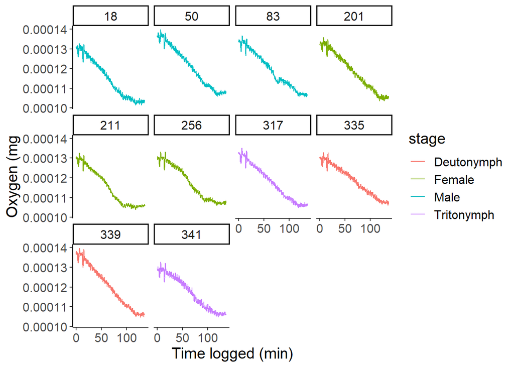

```r
ggplot(ox12, aes(x=logtime, y=oxymg,group=ind, color=stage))+ #MODIFY FOR EACH TRIAL
  geom_line()+
  theme_classic()+
  theme(text = element_text(size = 15))+
  #ylim(8,12) +
  facet_wrap(~ind)+
  xlab("Time logged (min)")+
  ylab("Oxygen (mg")
```

### 3.2.12 Trial 13

```r
# creating vector for columns names
cnames<-c("date", "time", "logtime", "oxygen", "phase", "amplitude", "temperature")

# creating vector for path
path<-"Data/Oxygen/Trial 13/" #MODIFY FOR EEACH TRIAL

# Creating list of file names
list <- list.files(path = path, pattern=".*txt") # creates the list of all the txt files in the directory

# Renaming files to remove the "-"
newname <- sub('-','', list) ## new name
file.rename(file.path(path,list), file.path(path, newname)) ## renaming it.
```

```
##  [1] TRUE TRUE TRUE TRUE TRUE TRUE TRUE TRUE TRUE TRUE
```

```r
# Creating list of file names again
list <- list.files(path = path, pattern=".*txt") # creates the list of all the txt files in the directory

#Reading all files at once
for (i in list) {
  filename <- paste0( "frame",sub(pattern = "(.*)\\..*$", replacement = "\\1", basename(i)))
  wd <- paste0(path, i)
  assign(filename, read.delim2(wd,sep=";", skip=38, header=F, col.names=cnames)) #CHECK FOR EACH TRIALS IF THE SAME NUMBRE OF ROWS APPLIES

}


# Merging all into a single table
pattern<-grep("framepstrial13",names(.GlobalEnv),value=TRUE) #MODIFY FOR EACH TRIAL
list2<-do.call("list",mget(pattern))

t13a<-bind_rows(list2, .id="id") #MODIFY FOR EACH TRIAL


# Adding and modifying data to phase files
t13b<-t13a %>% #MODIFY FOR EACH TRIAL
  select(c("id", "date", "time", "logtime", "phase")) %>%
  mutate(trial=13,#MODIFY FOR EACH TRIAL
         date=mdy(date), #formatting date
         datetime=paste0(date," ", time), #copying date and time together
         datetime=as_datetime(datetime, format="%Y-%m-%d %I:%M:%S %p")-minutes(9), #adjusting pc time to real time
         datetime2=round_date(datetime, unit="minute"),
         channel=case_when(str_detect(id, "ch10")~10, # Assigning channels
                       str_detect(id, "ch1")~1,
                       str_detect(id, "ch2")~2,
                       str_detect(id, "ch3")~3,
                       str_detect(id, "ch4")~4,
                       str_detect(id, "ch5")~5,
                       str_detect(id, "ch6")~6,
                       str_detect(id, "ch7")~7,
                       str_detect(id, "ch8")~8,
                       str_detect(id, "ch9")~9,
                       TRUE~0),
         ind=case_when(str_detect(id, "ch10")~1000, # Assigning individuals MODIFY FOR EACH TRIAL
                       str_detect(id, "ch1")~296,
                       str_detect(id, "ch2")~263,
                       str_detect(id, "ch3")~156,
                       str_detect(id, "ch4")~073,
                       str_detect(id, "ch5")~171,
                       str_detect(id, "ch6")~002,
                       str_detect(id, "ch7")~247,
                       str_detect(id, "ch8")~233,
                       str_detect(id, "ch9")~028,
                       TRUE~0),
         stage=case_when(str_detect(id, "ch10")~"NA",#Assigning stage MODIFY FOR EACH TRIAL
                       str_detect(id, "ch1")~"Deutonymph",
                         str_detect(id, "ch2")~"Tritonymph",
                       str_detect(id, "ch3")~"Male",
                       str_detect(id, "ch4")~"Male",
                       str_detect(id, "ch5")~"Deutonymph",
                       str_detect(id, "ch6")~"Tritonymph",
                       str_detect(id, "ch7")~"Female",
                       str_detect(id, "ch8")~"Female",
                       #str_detect(id, "ch9")~"",
                       TRUE~"Tritonymph"),
         weight=case_when(str_detect(id, "ch10")~1000, # Assigning weights MODIFY FOR EACH TRIAL
                       str_detect(id, "ch1")~0.272,
                       str_detect(id, "ch2")~0.764,
                       str_detect(id, "ch3")~0.656,
                       str_detect(id, "ch4")~1.18,
                       str_detect(id, "ch5")~0.361,
                       str_detect(id, "ch6")~0.767,
                       str_detect(id, "ch7")~1.256,
                       str_detect(id, "ch8")~1.693,
                       #str_detect(id, "ch9")~1.001,
                       TRUE~0.866),
         atm=round(33.864*28.55)) #MODIFY FOR EACH TRIAL: 33.864 * pressure in inHg

# Getting temperature for this trial
temp2<-all_corr %>%
  filter(trial==13) %>% #MODIFY FOR EACH TRIAL
  select(c("datetime2","datetime", "tempcorr", "ramp"))

#Merging phase and temperature data
t13<- full_join(t13b, temp2, by="datetime2", suffix=c("",".temp")) #MODIFY FOR EACH TRIAL


head(t13) #MODIFY FOR EACH TRIAL
```

|  | id | date | time | logtime | phase | trial | datetime | datetime2 | channel | ind | stage | weight | atm | datetime.temp | tempcorr | ramp |
| --- | --- | --- | --- | --- | --- | --- | --- | --- | --- | --- | --- | --- | --- | --- | --- | --- |
| 1 | framepstrial13ch10 | 2022-06-24 | 12:53:51 AM | 0.00 | 27.210 | 13 | 2022-06-24 00:44:51 | 2022-06-24 00:45:00 | 10 | 1000 | NA | 1000 | 967 | 2022-06-24 00:44:38 | 25.02521 | 0.251125 |
| 2 | framepstrial13ch10 | 2022-06-24 | 12:53:51 AM | 0.00 | 27.210 | 13 | 2022-06-24 00:44:51 | 2022-06-24 00:45:00 | 10 | 1000 | NA | 1000 | 967 | 2022-06-24 00:45:08 | 25.03830 | 0.251125 |
| 3 | framepstrial13ch10 | 2022-06-24 | 12:53:52 AM | 0.02 | 27.040 | 13 | 2022-06-24 00:44:52 | 2022-06-24 00:45:00 | 10 | 1000 | NA | 1000 | 967 | 2022-06-24 00:44:38 | 25.02521 | 0.251125 |
| 4 | framepstrial13ch10 | 2022-06-24 | 12:53:52 AM | 0.02 | 27.040 | 13 | 2022-06-24 00:44:52 | 2022-06-24 00:45:00 | 10 | 1000 | NA | 1000 | 967 | 2022-06-24 00:45:08 | 25.03830 | 0.251125 |
| 5 | framepstrial13ch10 | 2022-06-24 | 12:54:04 AM | 0.22 | 27.110 | 13 | 2022-06-24 00:45:04 | 2022-06-24 00:45:00 | 10 | 1000 | NA | 1000 | 967 | 2022-06-24 00:44:38 | 25.02521 | 0.251125 |
| 6 | framepstrial13ch10 | 2022-06-24 | 12:54:04 AM | 0.22 | 27.110 | 13 | 2022-06-24 00:45:04 | 2022-06-24 00:45:00 | 10 | 1000 | NA | 1000 | 967 | 2022-06-24 00:45:08 | 25.03830 | 0.251125 |

```r
#Estimating Oxygen
f<-pi/180
f
```

```
## [1] 0.01745329
```

```r
ox13<-t13 %>% #MODIFY FOR EACH TRIAL
  na.omit() %>%
  filter(ind < 900) %>%
  mutate(phase=as.numeric(phase),
         ind=as.factor(ind),
         logtime=as.numeric(logtime),
         phaseangle=62.14-0.08915*tempcorr,
         sternvolmer=0.04899+4.965*10^(-4)*tempcorr,
         bunsen=(48.998-1.335*tempcorr+2.755*10^(-2)*tempcorr^2-3.22*10^(-4)*tempcorr^3+1.598*10^(-6)*tempcorr^4)*10^(-3),
         tempK=tempcorr+273,
         watervapor=exp(52.57-(6690.9/tempK)-4.681*log(tempK)),
         oxysat=(tan((pi/180)*phaseangle)-tan((pi/180)*phase))/tan((pi/180)*phase)*sternvolmer,
         oxymgl=(atm-watervapor)/1013*oxysat*0.2095*bunsen*1000*(32/22.414)*10,
         oxymg=oxymgl*volume)

head(ox13) #MODIFY FOR EACH TRIAL
```

|  | id | date | time | logtime | phase | trial | datetime | datetime2 | channel | ind | stage | weight | atm | datetime.temp | tempcorr | ramp | phaseangle | sternvolmer | bunsen | tempK | watervapor | oxysat | oxymgl | oxymg |
| --- | --- | --- | --- | --- | --- | --- | --- | --- | --- | --- | --- | --- | --- | --- | --- | --- | --- | --- | --- | --- | --- | --- | --- | --- |
| 1 | framepstrial13ch1 | 2022-06-24 | 12:53:42 AM | 0.00 | 27.94 | 13 | 2022-06-24 00:44:42 | 2022-06-24 00:45:00 | 1 | 296 | Deutonymph | 0.272 | 967 | 2022-06-24 00:44:38 | 25.02521 | 0.251125 | 59.90900 | 0.06141502 | 0.02842309 | 298.0252 | 31.52321 | 0.1384180 | 10.86681 | 0.0001365564 |
| 2 | framepstrial13ch1 | 2022-06-24 | 12:53:42 AM | 0.00 | 27.94 | 13 | 2022-06-24 00:44:42 | 2022-06-24 00:45:00 | 1 | 296 | Deutonymph | 0.272 | 967 | 2022-06-24 00:45:08 | 25.03830 | 0.251125 | 59.90784 | 0.06142151 | 0.02841706 | 298.0383 | 31.54781 | 0.1384233 | 10.86464 | 0.0001365290 |
| 3 | framepstrial13ch1 | 2022-06-24 | 12:53:57 AM | 0.25 | 27.69 | 13 | 2022-06-24 00:44:57 | 2022-06-24 00:45:00 | 1 | 296 | Deutonymph | 0.272 | 967 | 2022-06-24 00:44:38 | 25.02521 | 0.251125 | 59.90900 | 0.06141502 | 0.02842309 | 298.0252 | 31.52321 | 0.1405420 | 11.03356 | 0.0001386518 |
| 4 | framepstrial13ch1 | 2022-06-24 | 12:53:57 AM | 0.25 | 27.69 | 13 | 2022-06-24 00:44:57 | 2022-06-24 00:45:00 | 1 | 296 | Deutonymph | 0.272 | 967 | 2022-06-24 00:45:08 | 25.03830 | 0.251125 | 59.90784 | 0.06142151 | 0.02841706 | 298.0383 | 31.54781 | 0.1405474 | 11.03135 | 0.0001386241 |
| 5 | framepstrial13ch1 | 2022-06-24 | 12:54:12 AM | 0.50 | 27.73 | 13 | 2022-06-24 00:45:12 | 2022-06-24 00:45:00 | 1 | 296 | Deutonymph | 0.272 | 967 | 2022-06-24 00:44:38 | 25.02521 | 0.251125 | 59.90900 | 0.06141502 | 0.02842309 | 298.0252 | 31.52321 | 0.1401998 | 11.00670 | 0.0001383142 |
| 6 | framepstrial13ch1 | 2022-06-24 | 12:54:12 AM | 0.50 | 27.73 | 13 | 2022-06-24 00:45:12 | 2022-06-24 00:45:00 | 1 | 296 | Deutonymph | 0.272 | 967 | 2022-06-24 00:45:08 | 25.03830 | 0.251125 | 59.90784 | 0.06142151 | 0.02841706 | 298.0383 | 31.54781 | 0.1402052 | 11.00449 | 0.0001382865 |

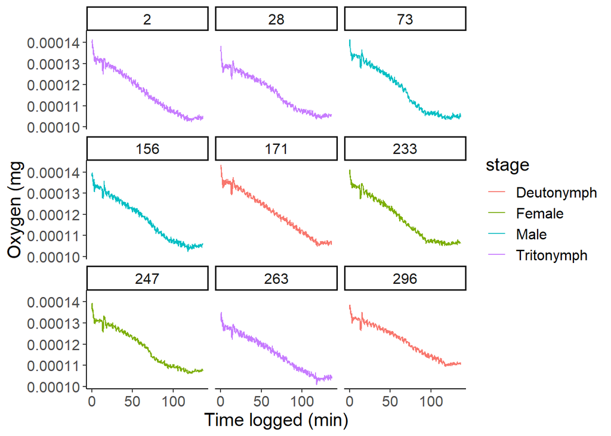

```r
ggplot(ox13, aes(x=logtime, y=oxymg,group=ind, color=stage))+ #MODIFY FOR EACH TRIAL
  geom_line()+
  theme_classic()+
  theme(text = element_text(size = 15))+
#  ylim(8,12) +
  facet_wrap(~ind)+
  xlab("Time logged (min)")+
  ylab("Oxygen (mg")
```

Go back to each trial and annotate the best beginning and end of trial, and change it in the temperature data, then re-run this analysis again, to only get the curves that actual pertain to the trial (i.e. get it from the start and also remove the tail when it warms up again at the end)

# 4 Merging trials into a single dataframe

> Once all trials were done, this part of the code merges them into a single file. Here we also removed the individuals that drowned during the trial, therefore, their traces might not reflect the same information than the rest.

```r
oxall<-bind_rows(ox2,ox3,ox4,ox5,ox6,ox7,ox8,ox9,ox10,ox11,ox12,ox13) %>%
filter(!ind%in%c("25","65", "231","82","121", "235")) # Drowned individuals



write.csv(oxall,"Outputs/oxygenall_aftercodedeletion.csv") #after code deletion: there was an issue and some changes on the code were not saved. This is the name the file received after that event
```

# 5 Trying which function to use before doing the analyses

> Here, I was exploring which polynomial function would fit the oxygen trace, in order to get the best fit to the curve and extract Topt, Ropt and activation energy later.  
> What these code chunks do is:  
> 1. Filter for a single individual 2. Then try diferent polynomial functions, with degrees from 2 to 10,and see how they fit the data by plotting and looking at the adjusted r-squared values  
> 3. Estimate the 1st and second derivative for one of the polynomials that best fitted the oxygen trace 4. Get the inflection points for the second derivatives (the point where the second derivative crosses zero, which would mark the places where the first derivative shanges the sign of the slope)

## 5.1 On individual 232

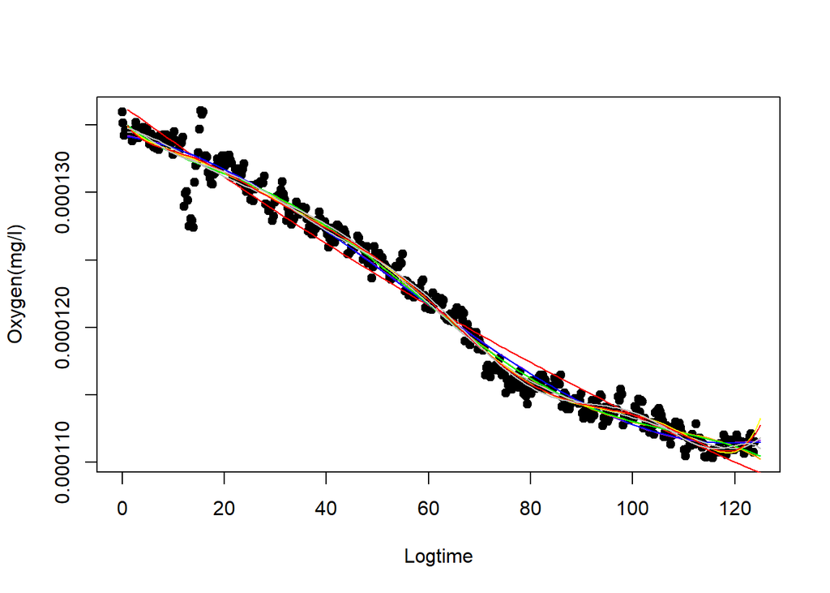

```r
# Filtering for a single individuals to just see the fit
func<-ox7%>%
  filter(ind==232) %>%
  group_by(logtime) %>%
  filter(duplicated(logtime|n()==2))

#Trying different curves
fit2<-lm(oxymg~poly(logtime, 2, raw=TRUE), data=func)
fit3<-lm(oxymg~poly(logtime, 3, raw=TRUE), data=func)
fit4<-lm(oxymg~poly(logtime, 4, raw=TRUE), data=func)
fit5<-lm(oxymg~poly(logtime, 5, raw=TRUE), data=func)
fit6<-lm(oxymg~poly(logtime, 6, raw=TRUE), data=func)
fit7<-lm(oxymg~poly(logtime, 7, raw=TRUE), data=func)
fit8<-lm(oxymg~poly(logtime, 8, raw=TRUE), data=func)
fit9<-lm(oxymg~poly(logtime, 9, raw=TRUE), data=func)
fit10<-lm(oxymg~poly(logtime, 10, raw=TRUE), data=func)

# CReating a dataframe to build the prediction
logtime <- seq(1, 125, length=125)

# Plotting each predicted function line to the real data
plot(func$logtime, func$oxymg, pch=19, xlab='Logtime', ylab='Oxygen(mg/l)')
lines(logtime, predict(fit7, data.frame(x=logtime)), col='grey')
lines(logtime, predict(fit2, data.frame(x=logtime)), col='red')
lines(logtime, predict(fit3, data.frame(x=logtime)), col='purple')
lines(logtime, predict(fit4, data.frame(x=logtime)), col='blue')
lines(logtime, predict(fit5, data.frame(x=logtime)), col='orange')
lines(logtime, predict(fit6, data.frame(x=logtime)), col='green')
lines(logtime, predict(fit7, data.frame(x=logtime)), col='grey')
lines(logtime, predict(fit8, data.frame(x=logtime)), col='yellow')
lines(logtime, predict(fit9, data.frame(x=logtime)), col='red')
lines(logtime, predict(fit10, data.frame(x=logtime)), col='grey')
```

```r
#calculated adjusted R-squared of each model

# The adjusted r squared is the percent of the variance of Y intact after subtracting the error of the model. The more the R Squared value the better the model is for that data frame.
summary(fit2)$adj.r.squared
```

```
## [1] 0.9726057
```

```r
summary(fit3)$adj.r.squared
```

```
## [1] 0.9836784
```

```r
summary(fit4)$adj.r.squared
```

```
## [1] 0.9836592
```

```r
summary(fit5)$adj.r.squared
```

```
## [1] 0.985174
```

```r
summary(fit6)$adj.r.squared
```

```
## [1] 0.9851743
```

```r
summary(fit7)$adj.r.squared
```

```
## [1] 0.9860696
```

```r
summary(fit8)$adj.r.squared
```

```
## [1] 0.9867469
```

```r
summary(fit9)$adj.r.squared
```

```
## [1] 0.9867864
```

```r
summary(fit10)$adj.r.squared
```

```
## [1] 0.9873106
```

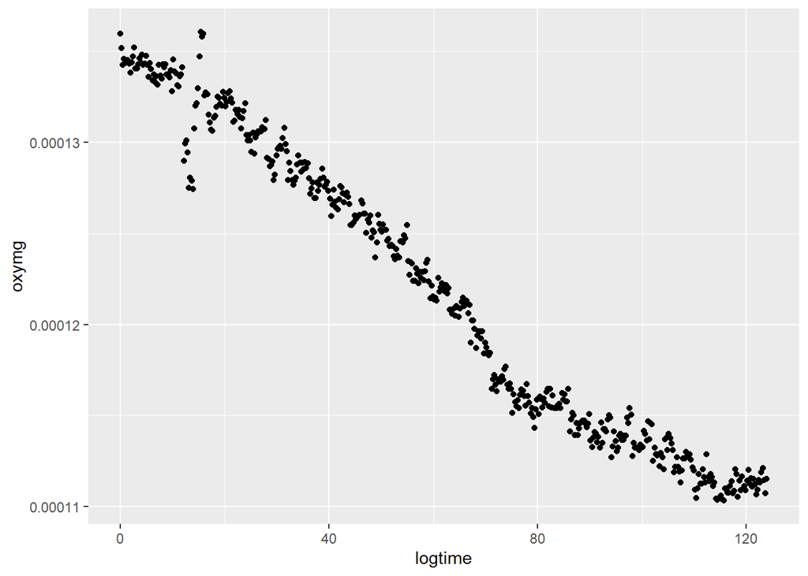

```r
coef7<-as.data.frame(fit7$coefficients)
a0<-coef7[1,1]
a1<-coef7[2,1]
a2<-coef7[3,1]
a3<-coef7[4,1]
a4<-coef7[5,1]
a5<-coef7[6,1]
a6<-coef7[7,1]
a7<-coef7[8,1] #cambiar a A
x<-func$logtime
form7<-expression((a7*x^7)+(a6*x^6)+(a5*x^5)+(a4*x^4)+(a3*x^3)+(a2*x^2)+(a1*x^1)+(a0*x^0))
d7<-D(form7, "x")
d7b<-D(d7, "x")

ggplot(aes(x=logtime, y=oxymg), data=func)+geom_point()
```

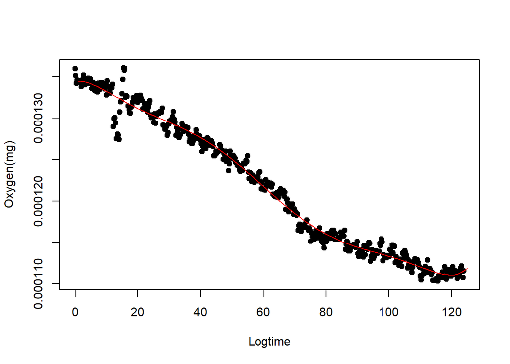

```r
plot(x, func$oxymg, pch=19, xlab='Logtime', ylab='Oxygen(mg)')
lines(logtime, predict(fit7, data.frame(x=logtime)), col='red')
```

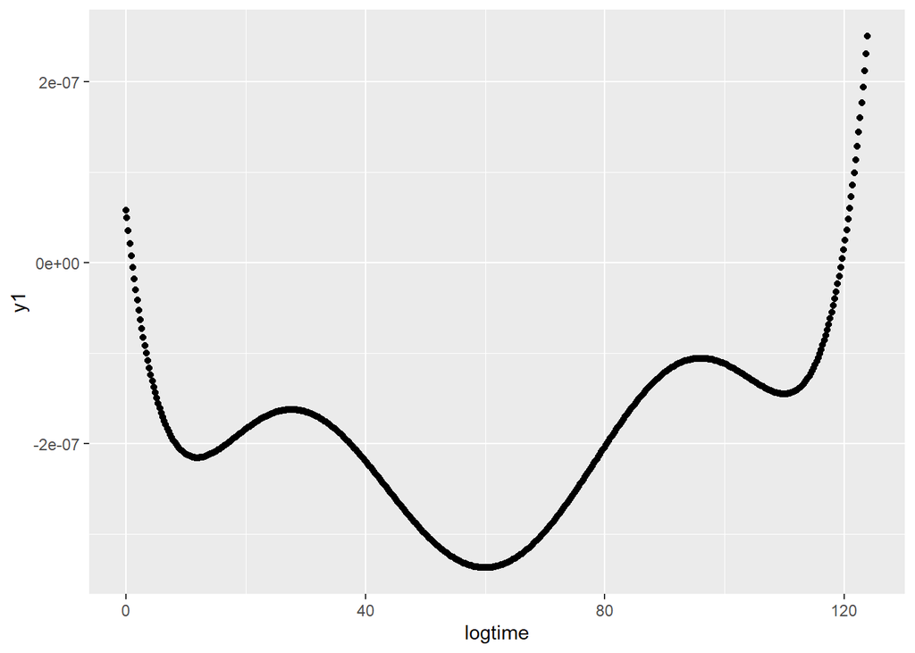

```r
#Primera derivada: tasa con la que consume oxigeno
d7b.data<-as.data.frame(eval(d7, envir=as.data.frame(x)))
colnames(d7b.data)<-"y1"
d7b.data$logtime<-func$logtime
ggplot(aes(x=logtime, y=y1), data=d7b.data)+geom_point()
```

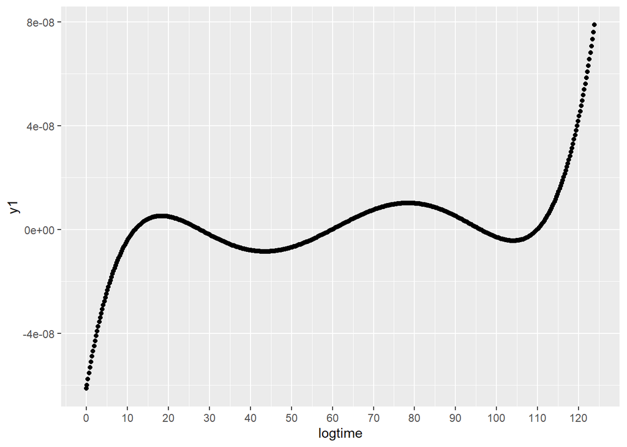

```r
#Segunda derivada: cruce con y=0 son los punto de cambio, puntos de inflexion donde la pendiente cambia hacia arriva o hacia abajo
d7b.data<-as.data.frame(eval(d7b, envir=as.data.frame(x)))
colnames(d7b.data)<-"y1"
d7b.data$logtime<-func$logtime
ggplot(aes(x=logtime, y=y1), data=d7b.data)+geom_point()+scale_x_continuous(breaks=c(0,10, 20, 30, 40, 50, 60, 70, 80, 90, 100, 110, 120))
```

```r
# Finding the values at which the second derivative=0
f=function(x) eval(d7b)
uniroot(f, c(0,125))
```

```
## $root
## [1] 59.9636
##
## $f.root
## [1] -2.227179e-15
##
## $iter
## [1] 8
##
## $init.it
## [1] NA
##
## $estim.prec
## [1] 6.103516e-05
```

```r
inflection<-polyroot(c((a2 *2), (a3 *3 * 2 ),(a4* 4 * 3 ), (a5 *5 * 4) , (a6 * 6 * 5 ), (a7 * 7 * 6 )))
inflec<-as.data.frame(inflection)
```

## 5.2 On individual 87

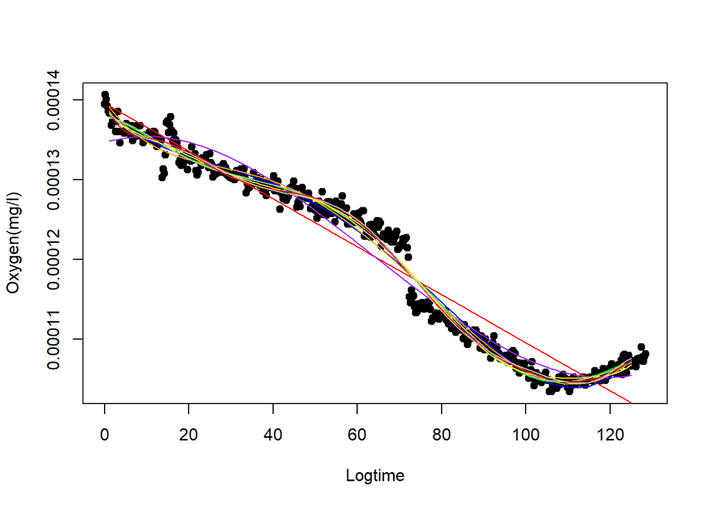

```r
# Filtering for a single individuals to just see the fit
func<-ox3%>%
  filter(ind=="87")# %>%
  #group_by(logtime) %>%
  #filter(duplicated(logtime|n()==2))

#Trying different curves
fit2<-lm(oxymg~poly(logtime, 2, raw=TRUE), data=func)
fit3<-lm(oxymg~poly(logtime, 3, raw=TRUE), data=func)
fit4<-lm(oxymg~poly(logtime, 4, raw=TRUE), data=func)
fit5<-lm(oxymg~poly(logtime, 5, raw=TRUE), data=func)
fit6<-lm(oxymg~poly(logtime, 6, raw=TRUE), data=func)
fit7<-lm(oxymg~poly(logtime, 7, raw=TRUE), data=func)
fit8<-lm(oxymg~poly(logtime, 8, raw=TRUE), data=func)
fit9<-lm(oxymg~poly(logtime, 9, raw=TRUE), data=func)
fit10<-lm(oxymg~poly(logtime, 10, raw=TRUE), data=func)

# CReating a dataframe to build the prediction
logtime <- seq(1, 125, length=125)

# Plotting each predicted function line to the real data
plot(func$logtime, func$oxymg, pch=19, xlab='Logtime', ylab='Oxygen(mg/l)')
lines(logtime, predict(fit7, data.frame(x=logtime)), col='grey')
lines(logtime, predict(fit2, data.frame(x=logtime)), col='red')
lines(logtime, predict(fit3, data.frame(x=logtime)), col='purple')
lines(logtime, predict(fit4, data.frame(x=logtime)), col='blue')
lines(logtime, predict(fit5, data.frame(x=logtime)), col='orange')
lines(logtime, predict(fit6, data.frame(x=logtime)), col='green')
lines(logtime, predict(fit7, data.frame(x=logtime)), col='grey')
lines(logtime, predict(fit8, data.frame(x=logtime)), col='yellow')
lines(logtime, predict(fit9, data.frame(x=logtime)), col='red')
lines(logtime, predict(fit10, data.frame(x=logtime)), col='grey')
```

```r
#calculated adjusted R-squared of each model

# The adjusted r squared is the percent of the variance of Y intact after subtracting the error of the model. The more the R Squared value the better the model is for that data frame.
summary(fit2)$adj.r.squared
```

```
## [1] 0.9427353
```

```r
summary(fit3)$adj.r.squared
```

```
## [1] 0.9698782
```

```r
summary(fit4)$adj.r.squared
```

```
## [1] 0.9854856
```

```r
summary(fit5)$adj.r.squared
```

```
## [1] 0.9862446
```

```r
summary(fit6)$adj.r.squared
```

```
## [1] 0.9880651
```

```r
summary(fit7)$adj.r.squared
```

```
## [1] 0.9881283
```

```r
summary(fit8)$adj.r.squared
```

```
## [1] 0.9889078
```

```r
summary(fit9)$adj.r.squared
```

```
## [1] 0.9895974
```

```r
summary(fit10)$adj.r.squared
```

```
## [1] 0.9899222
```

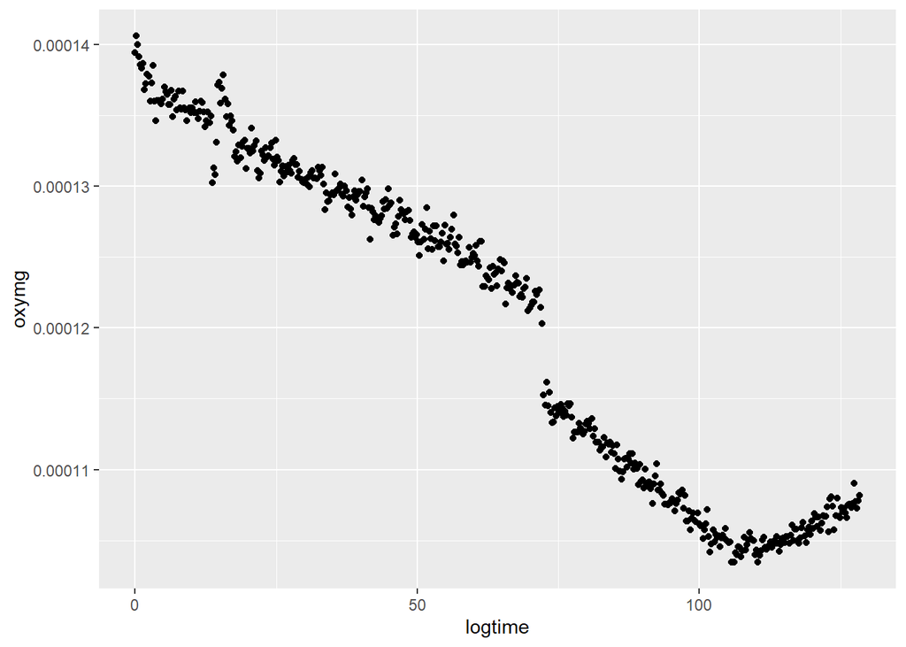

```r
coef7<-as.data.frame(fit7$coefficients)
a0<-coef7[1,1]
a1<-coef7[2,1]
a2<-coef7[3,1]
a3<-coef7[4,1]
a4<-coef7[5,1]
a5<-coef7[6,1]
a6<-coef7[7,1]
a7<-coef7[8,1] #cambiar a A
x<-func$logtime
form7<-expression((a7*x^7)+(a6*x^6)+(a5*x^5)+(a4*x^4)+(a3*x^3)+(a2*x^2)+(a1*x^1)+(a0*x^0))
d7<-D(form7, "x")
d7b<-D(d7, "x")

ggplot(aes(x=logtime, y=oxymg), data=func)+geom_point()
```

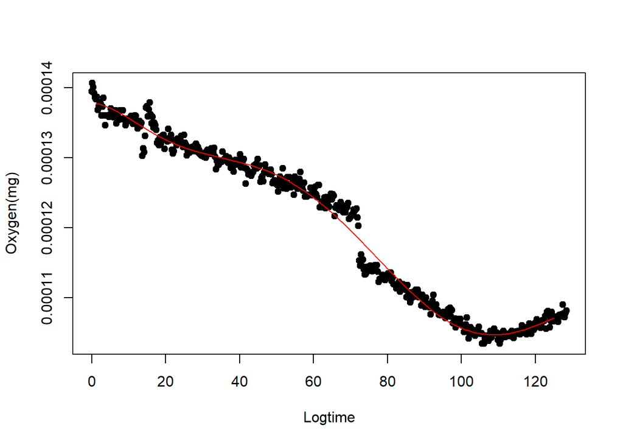

```r
plot(x, func$oxymg, pch=19, xlab='Logtime', ylab='Oxygen(mg)')
lines(logtime, predict(fit7, data.frame(x=logtime)), col='red')
```

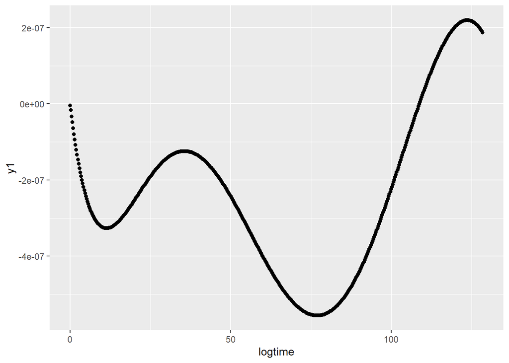

```r
#Primera derivada: tasa con la que consume oxigeno
d7b.data<-as.data.frame(eval(d7, envir=as.data.frame(x)))
colnames(d7b.data)<-"y1"
d7b.data$logtime<-func$logtime
ggplot(aes(x=logtime, y=y1), data=d7b.data)+geom_point()
```

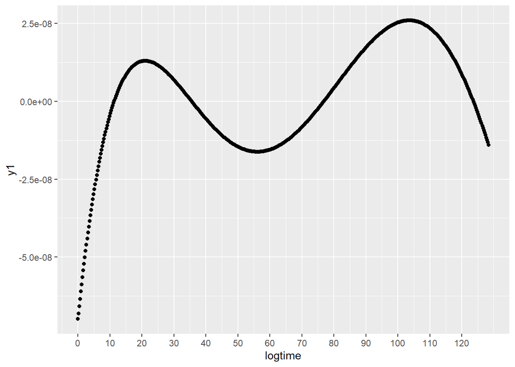

```r
#Segunda derivada: cruce con y=0 son los punto de cambio, puntos de inflexion donde la pendiente cambia hacia arriba o hacia abajo
d7b.data<-as.data.frame(eval(d7b, envir=as.data.frame(x)))
colnames(d7b.data)<-"y1"
d7b.data$logtime<-func$logtime
ggplot(aes(x=logtime, y=y1), data=d7b.data)+geom_point()+scale_x_continuous(breaks=c(0,10, 20, 30, 40, 50, 60, 70, 80, 90, 100, 110, 120))
```

```r
# Finding the values at which the second derivative=0
#f=function(x) eval(d7b)
#uniroot(f, c(0,125))

inflection<-polyroot(c((a2 *2), (a3 *3 * 2 ),(a4* 4 * 3 ), (a5 *5 * 4) , (a6 * 6 * 5 ), (a7 * 7 * 6 )))
inflection
```

```
## [1]  11.34936-0i  35.54297+0i  76.89940-0i 123.63101+0i 179.91697-0i
```

```r
inflec<-as.data.frame(inflection)
#inflec$inflection<-as.numeric*inflec$inflection
```

# 6 Trimming traces with weird patterns

> Some traces have some weird drops/fluctuations of oxygen in the middle of the trace. In order to get a better idea of the general oxygen trace, John reccomended I cut those portions of the trace before fitting the polynomial function to the data. After cutting the traces, I removed the individuals from the original dataset and then add the new, trimmed traces. This created the file “oxall_trimmed.csv”

## 6.1 Calling the csv file of the oxygen calculations to avoid running the whole code above

```r
#Calling csv file to avoid running the whole code
oxall<-read.csv("./Outputs/oxygenall_aftercodedeletion.csv") #Use this one for trimming the traces, but for everything else use the one named: "oxall_trimmed.csv", which is the one produced at the end of this section of the code
```

## 6.2 Individual 22

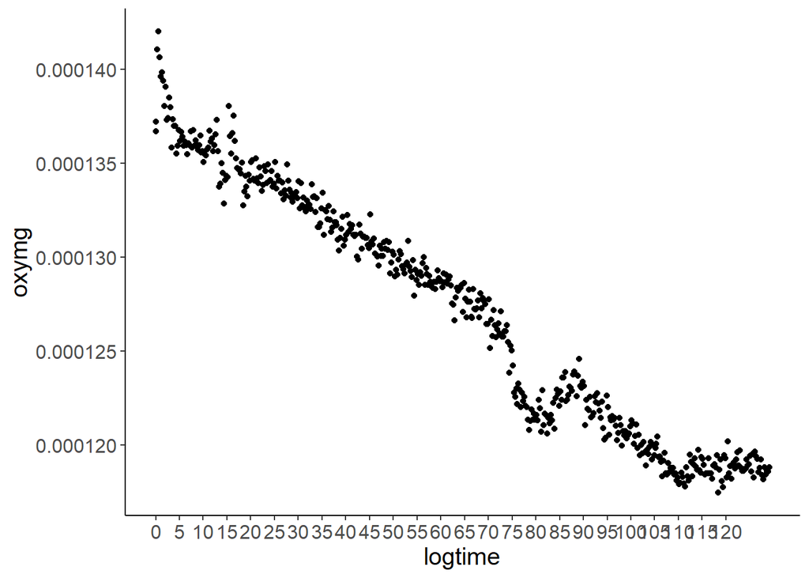

```r
ind22<-oxall %>%
filter(ind=="22")
ggplot(aes(x=logtime, y=oxymg), data=ind22)+geom_point() +theme_classic() + theme(text=element_text(size=15))+scale_x_continuous(breaks = seq(0, 120, by = 5))
```

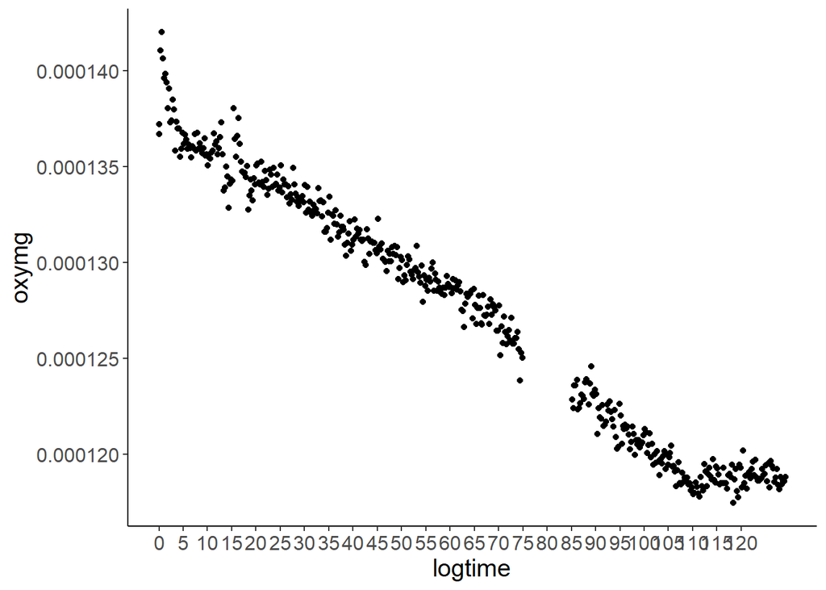

```r
ind22<-ind22 %>%
filter(!between(logtime, 75, 85))
ggplot(aes(x=logtime, y=oxymg), data=ind22)+geom_point() +theme_classic() + theme(text=element_text(size=15))+scale_x_continuous(breaks = seq(0, 120, by = 5))
```

## 6.3 Individual 83

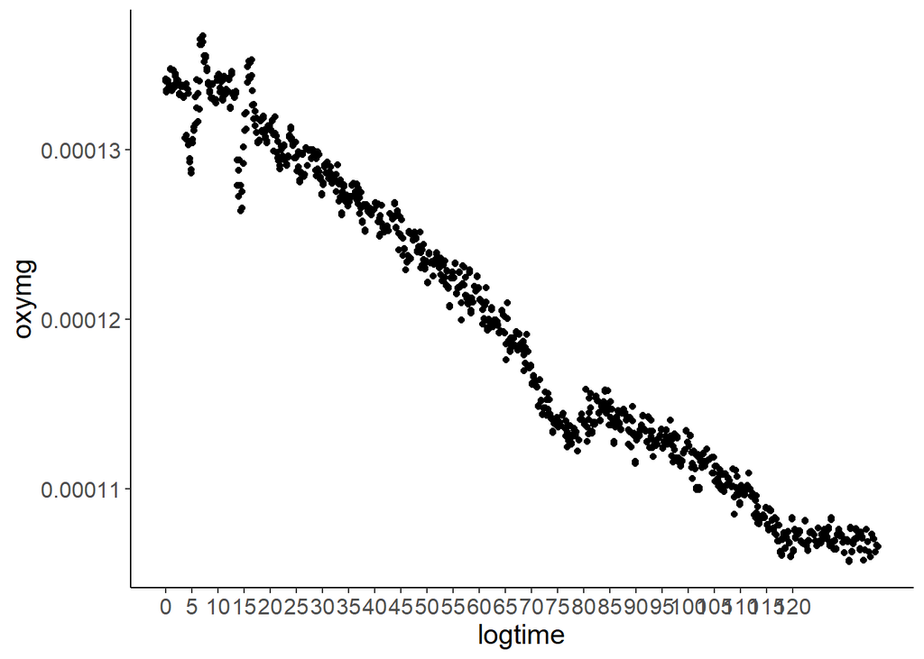

```r
ind83<-oxall %>%
filter(ind=="83")
ggplot(aes(x=logtime, y=oxymg), data=ind83)+geom_point() +theme_classic() + theme(text=element_text(size=15))+scale_x_continuous(breaks = seq(0, 120, by = 5))
```

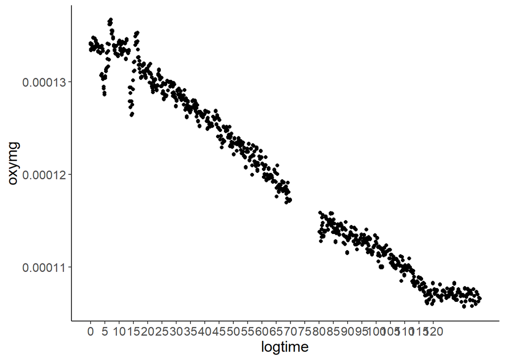

```r
ind83<-ind83 %>%
filter(!between(logtime, 70, 80))
ggplot(aes(x=logtime, y=oxymg), data=ind83)+geom_point() +theme_classic() + theme(text=element_text(size=15))+scale_x_continuous(breaks = seq(0, 120, by = 5))
```

## 6.4 Individual 131

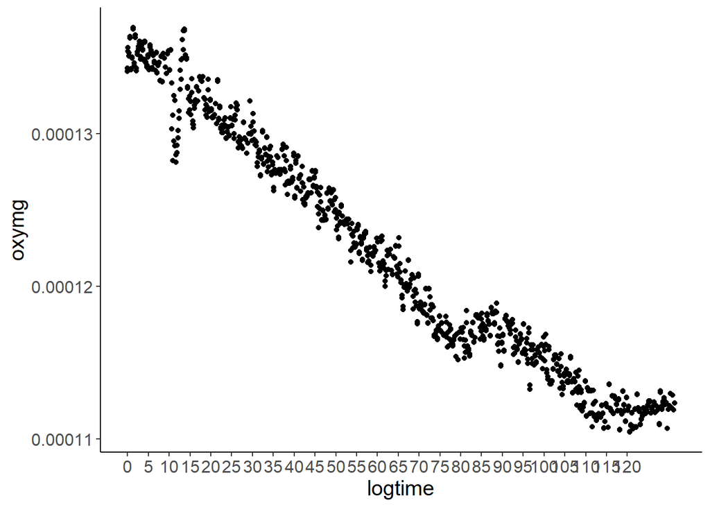

```r
ind131<-oxall %>%
filter(ind=="131")
ggplot(aes(x=logtime, y=oxymg), data=ind131)+geom_point() +theme_classic() + theme(text=element_text(size=15))+scale_x_continuous(breaks = seq(0, 120, by = 5))
```

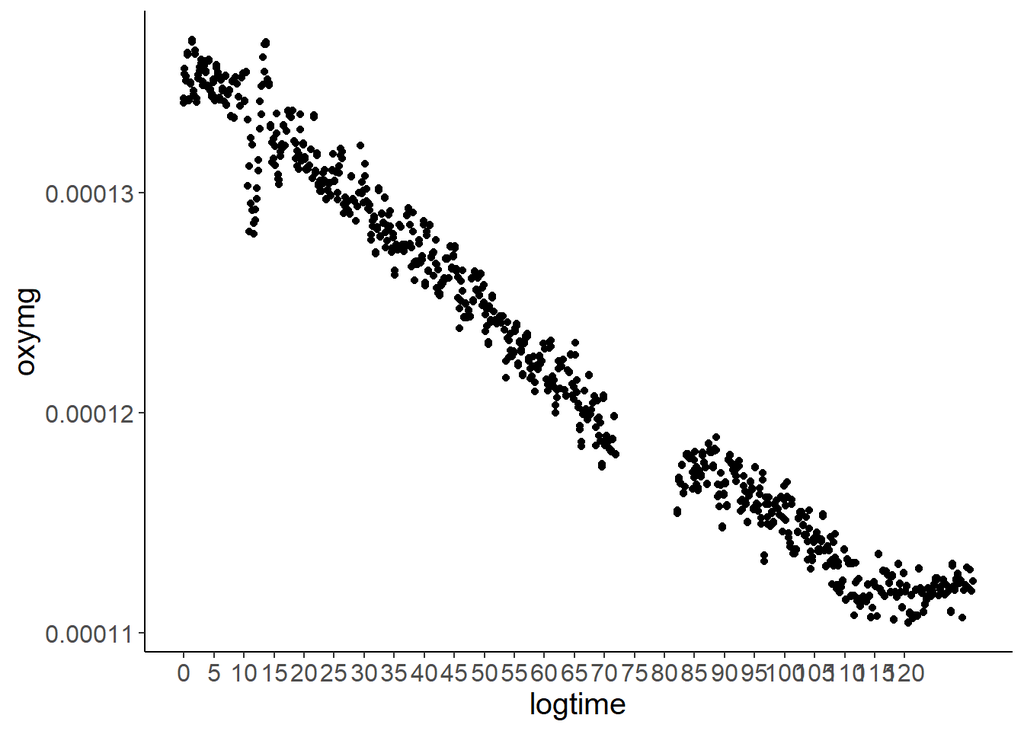

```r
ind131<-ind131 %>%
filter(!between(logtime, 72, 82))
ggplot(aes(x=logtime, y=oxymg), data=ind131)+geom_point() +theme_classic() + theme(text=element_text(size=15))+scale_x_continuous(breaks = seq(0, 120, by = 5))
```

## 6.5 Individual 136

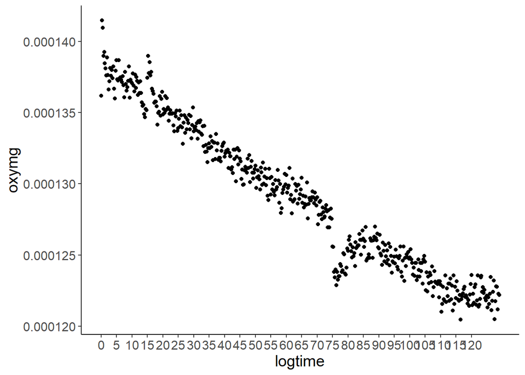

```r
ind136<-oxall %>%
filter(ind=="136")
ggplot(aes(x=logtime, y=oxymg), data=ind136)+geom_point() +theme_classic() + theme(text=element_text(size=15))+scale_x_continuous(breaks = seq(0, 120, by = 5))
```

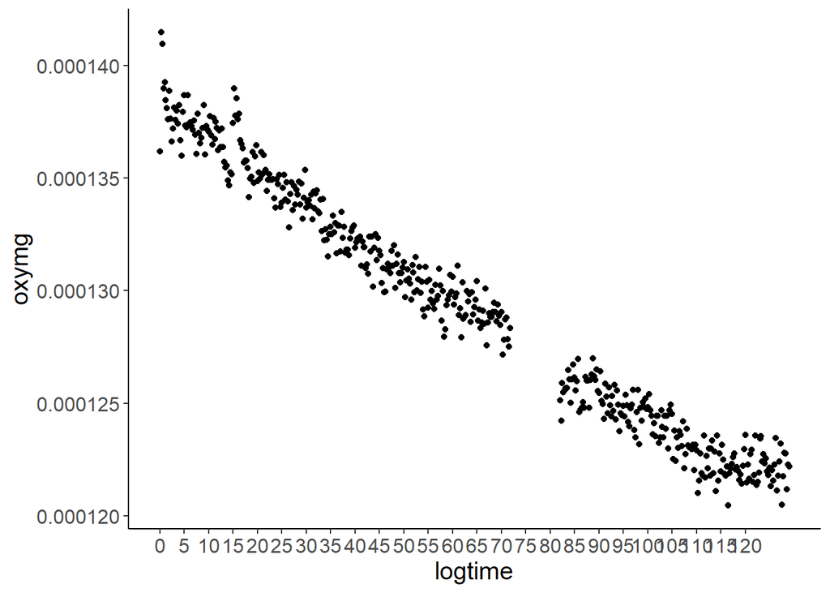

```r
ind136<-ind136 %>%
filter(!between(logtime, 72, 82))
ggplot(aes(x=logtime, y=oxymg), data=ind136)+geom_point() +theme_classic() + theme(text=element_text(size=15))+scale_x_continuous(breaks = seq(0, 120, by = 5))
```

## 6.6 Individual 159

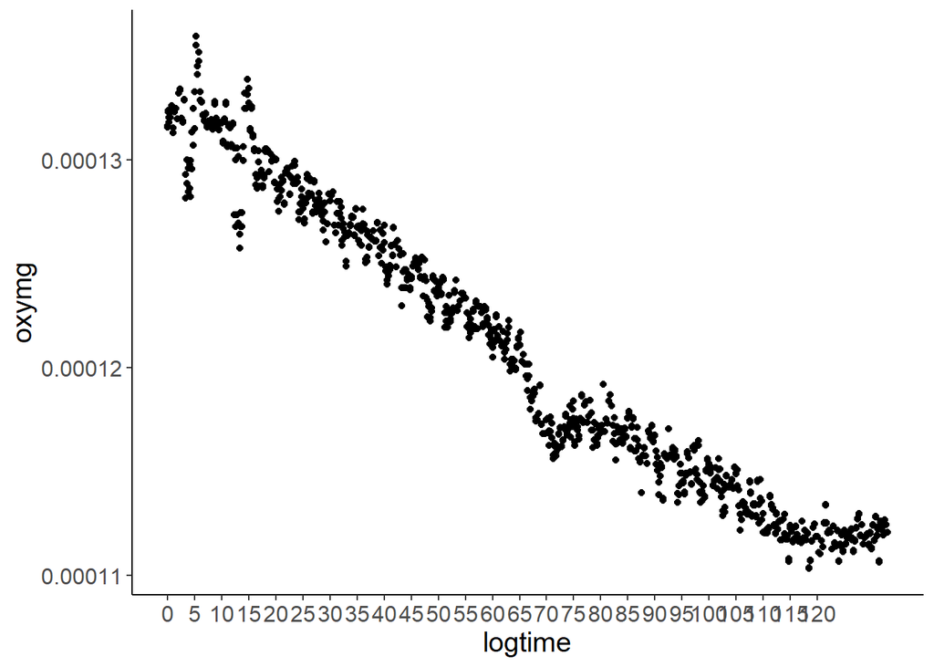

```r
ind159<-oxall %>%
filter(ind=="159")
ggplot(aes(x=logtime, y=oxymg), data=ind159)+geom_point() +theme_classic() + theme(text=element_text(size=15))+scale_x_continuous(breaks = seq(0, 120, by = 5))
```

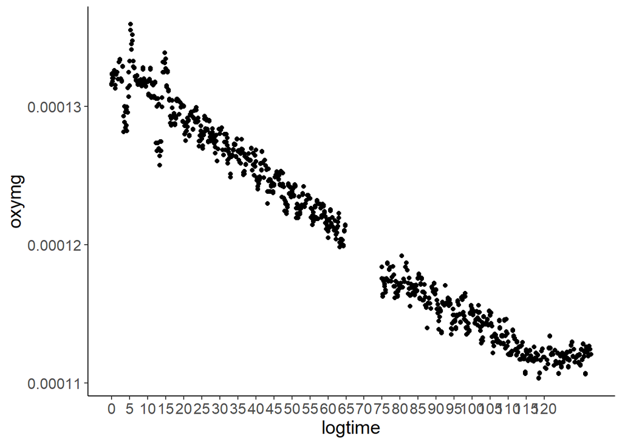

```r
ind159<-ind159 %>%
filter(!between(logtime, 65, 75))
ggplot(aes(x=logtime, y=oxymg), data=ind159)+geom_point() +theme_classic() + theme(text=element_text(size=15))+scale_x_continuous(breaks = seq(0, 120, by = 5))
```